# HELCOM adjustments

**HELCOM adjustments**

### Water

#### Data summary

Here is a summary of the submissions for each country, first by determinand and then by year.

```r
water_data$data %>%
  with(table(country, determinand)) %>%
  print(zero.print = ".")
```

```
           determinand
country       CD   PB PFOS TBSN+
  Estonia     29   29   28    23
  Germany   1371 1349    5   156
  Lithuania  267  267   47    55
  Poland     862  854   36   375
  Russia      23   23    .     .
```

```r
water_data$data %>%
  with(table(country, year)) %>%
  print(zero.print = ".")
```

```
           year
country     1995 1998 1999 2000 2003 2004 2005 2006 2007 2008 2009 2010 2011 2012 2013 2014 2015 2016
  Estonia      .    .    .    .    .    .    .    .    .    .    .    .    .    .    .    .    .    .
  Germany      .   88   87  176   73  154  158  114  138  206  189  213   82   98  134   82  122  121
  Lithuania    .    .    .    .    .    .    .    .   46   46   48   38   49   52   42   42   66   16
  Poland       .    .    .    .    .    .    .    .    .    .    .    .  133  181   72  144   72  479
  Russia       4   42    .    .    .    .    .    .    .    .    .    .    .    .    .    .    .    .
           year
country     2017 2018 2019 2020 2021
  Estonia     17    4   36   20   32
  Germany    142  136  129  135  104
  Lithuania    .   81   46   64    .
  Poland     540  143  159  108   96
  Russia       .    .    .    .    .
```

#### Matrix issues

Here is a summary of the matrix and filtration data. Data with matrix SPM are deleted.

```r
water_data$data <- mutate(
  water_data$data,
  matrix = matrx_std,
  metpt = metpt_std
)

water_data$data %>%
  with(table(matrix, filtered)) %>%
  print(zero.print = ".")
```

```
      filtered
matrix   No  Yes
   SPM   36    .
   WT  2074 3689
```

```r
water_data$data <- filter(
  water_data$data,
  matrix == "WT"
)
```

#### Duplicate records

The following samples have duplicated records - only the first is retained.

```r
wk <- water_data$data %>%
  group_by(sample, determinand, filtered) %>%
  filter(n() >= 2) %>%
  ungroup()

wk %>%
  select(country, year, station_name, sample, determinand, filtered, replicate, value) %>%
  arrange(country, year, sample, determinand, replicate) %>%
  as.data.frame() %>%
  DT::datatable(options = DT_options, rownames = FALSE)
```

| country | year | station_name | sample | determinand | filtered | replicate | value |
| --- | --- | --- | --- | --- | --- | --- | --- |
| Germany | 2005 | OMBMPM2 | 319540 | CD | No | 21310563 | 850 |
| Germany | 2005 | OMBMPM2 | 319540 | CD | No | 21310564 | 850 |
| Germany | 2005 | OMBMPM2 | 319540 | CD | Yes | 21317207 | 0.0133 |
| Germany | 2005 | OMBMPM2 | 319540 | CD | Yes | 21317208 | 0.0133 |
| Germany | 2005 | OMBMPM1 | 319601 | CD | No | 21310571 | 2990 |
| Germany | 2005 | OMBMPM1 | 319601 | CD | No | 21310572 | 2990 |
| Germany | 2005 | OMBMPM1 | 319601 | CD | Yes | 21317213 | 0.0193 |
| Germany | 2005 | OMBMPM1 | 319601 | CD | Yes | 21317214 | 0.0193 |
| Germany | 2005 | OMBMPK8 | 319629 | CD | No | 21310583 | 860 |
| Germany | 2005 | OMBMPK8 | 319629 | CD | No | 21310584 | 860 |

[output cut: 42 more lines]

```r
wk_rep <- wk$replicate

wk_keep <- wk %>%
  select(sample, determinand, filtered, replicate, station_name, value) %>%
  arrange(replicate) %>%
  distinct(sample, determinand, filtered, value, .keep_all = TRUE) %>%
  pull(replicate)

wk_drop <- setdiff(wk_rep, wk_keep)

water_data$data <- filter(
  water_data$data,
  !replicate %in% wk_drop
)
```

#### Filtration issues

Here’s a summary of whether the data have been filtered or not by determinand. All PFOS and TBSN+ are unfiltered, which is fine. However, there could be issues with the metals data, since there are both filtered (preferred) and unfiltered samples.

```r
water_data$data %>%
  with(table(determinand, filtered)) %>%
  print(zero.print = ".")
```

```
           filtered
determinand   No  Yes
      CD     677 1831
      PB     659 1845
      PFOS   116    .
      TBSN+  609    .
```

Here’s a more detailed look at the metals data (having excluded the Russian data which are too old).

- Estonia: all samples are filtered.
- Germany: a real mixture which is explored more below.
- Lithuania: the only unfiltered data are from 2007 (the first year of data). Maybe these were filtered data and have been submitted incorrectly. For now they are treated as unfiltered (and will drop out of the assessment because there are no unfiltered data in the last six monitoring years)
- Poland: all samples are filtered.

```r
wk <- filter(
  water_data$data,
  country != "Russia",
  determinand %in% c("CD", "PB")
)

wk %>%
  with(table(filtered, country)) %>%
  print(zero.print = ".")
```

```
        country
filtered Estonia Germany Lithuania Poland
     No        .    1244        46      .
     Yes      58    1414       488   1716
```

```r
wk %>%
  with(table(filtered, year, country)) %>%
  print(zero.print = ".")
```

```
, , country = Estonia

        year
filtered 1998 1999 2000 2003 2004 2005 2006 2007 2008 2009 2010 2011 2012 2013 2014 2015 2016 2017 2018
     No     .    .    .    .    .    .    .    .    .    .    .    .    .    .    .    .    .    .    .
     Yes    .    .    .    .    .    .    .    .    .    .    .    .    .    .    .    .    .   12    2
        year
filtered 2019 2020 2021
     No     .    .    .
     Yes   18   10   16

, , country = Germany

        year
filtered 1998 1999 2000 2003 2004 2005 2006 2007 2008 2009 2010 2011 2012 2013 2014 2015 2016 2017 2018
     No    88   87  176   73  154  119   24   24   32   32   69   62   36   32   24   32   20   44   48
     Yes    .    .    .    .    .   13   90  114  174  121  144   20   62  102   58   90   96   68   66
        year
filtered 2019 2020 2021
     No    22   46    .
     Yes   72   58   66

, , country = Lithuania

        year
filtered 1998 1999 2000 2003 2004 2005 2006 2007 2008 2009 2010 2011 2012 2013 2014 2015 2016 2017 2018
     No     .    .    .    .    .    .    .   46    .    .    .    .    .    .    .    .    .    .    .
     Yes    .    .    .    .    .    .    .    .   46   48   34   40   40   42   42   34    .    .   58
        year
filtered 2019 2020 2021
     No     .    .    .
     Yes   46   58    .

, , country = Poland

        year
filtered 1998 1999 2000 2003 2004 2005 2006 2007 2008 2009 2010 2011 2012 2013 2014 2015 2016 2017 2018
     No     .    .    .    .    .    .    .    .    .    .    .    .    .    .    .    .    .    .    .
     Yes    .    .    .    .    .    .    .    .    .    .    .  123  151   72  144   72  336  348  143
        year
filtered 2019 2020 2021
     No     .    .    .
     Yes  147   96   84
```

##### German metals data

Here are the stations with metals data in the last six monitoring years (2016-2021); the second column shows whether the metal samples in this period were all filtered, all unfiltered, or a mixture.

```r
wk <- wk %>%
  filter(country == "Germany") %>%
  group_by(station_name) %>%
  filter(max(year) >= 2016) %>%
  ungroup()


wk_fun <- function(x) {
  if (all(x == "Yes")) return("filtered")
  if (all(x == "No")) return("unfiltered")
  "mixture"
}

wk1 <- wk %>%
  filter(year >= 2016) %>%
  group_by(station_name) %>%
  summarise(type = wk_fun(filtered), .groups = "drop_last")

as.data.frame(wk1) %>%
  DT::datatable(options = DT_options, rownames = FALSE)
```

| station_name | type |
| --- | --- |
| BMP K4 | filtered |
| Oderbank | filtered |
| OM225019 | unfiltered |
| OM225025 | unfiltered |
| OM225049 | unfiltered |
| OM225054 | unfiltered |
| OM225059 | unfiltered |
| OM225103 | unfiltered |
| OM225109 | unfiltered |
| OM707 | unfiltered |

[output cut: 17 more lines]

There are three stations where there is a mixture. Here are the full records of samples at these stations. These look intentional. Filtered and unfiltered samples will be analysed as separate time series.

```r
wk_id <- wk1 %>%
  filter(type == "mixture") %>%
  pull(station_name)

wk %>%
  filter(station_name %in% wk_id) %>%
  with(table(filtered, year, station_name)) %>%
  print(zero.print = ".")
```

```
, , station_name = OMBMPM2

        year
filtered 2005 2006 2007 2008 2009 2010 2011 2012 2013 2014 2015 2016 2017 2018 2019 2020
     No     1    2    4    4    4    8    4    4    4    2    2    2    4    4    2    4
     Yes    1    2    2    2    4    .    .    .    .    .    .    2    .    .    .    .

, , station_name = OMBMPN3

        year
filtered 2005 2006 2007 2008 2009 2010 2011 2012 2013 2014 2015 2016 2017 2018 2019 2020
     No     .    .    .    4    4    8    4    4    4    2    4    2    4    4    2    2
     Yes    .    .    .    2    4    .    .    .    .    .    .    2    .    .    .    .

, , station_name = OMO22

        year
filtered 2005 2006 2007 2008 2009 2010 2011 2012 2013 2014 2015 2016 2017 2018 2019 2020
     No     .    .    4    4    4    4    4    4    4    2    2    2    4    4    2    4
     Yes    .    .    .    .    .   20    .    .    .    .    .    .   12    .    .    8
```

#### Zero concentrations

Some metals concentrations from Lithuania in 2008 have been reported with value = 0. These measurements are less than the LoQ (Nijole 22 August) so the value has been replaced by the LoQ. (There are no uncertainties reported, so there is no need to adjust these.)

```r
water_data$data <- mutate(
  water_data$data,
  .id = value == 0
)

if (sum(water_data$data$.id) != 23) {
  stop("something has changed - investigate")
}

water_data$data %>%
  filter(.id) %>%
  select(
    country, year, determinand, value, qflag, limit_detection,
    limit_quantification, uncertainty, methodUncertainty
  ) %>%
  as.data.frame() %>%
  DT::datatable(options = DT_options, rownames = FALSE)
```

| country | year | determinand | value | qflag | limit_detection | limit_quantification | uncertainty | methodUncertainty |
| --- | --- | --- | --- | --- | --- | --- | --- | --- |
| Lithuania | 2008 | PB | 0 | &lt;~Q |  | 1.2 |  |  |
| Lithuania | 2008 | CD | 0 | &lt;~Q |  | 0.08 |  |  |
| Lithuania | 2008 | PB | 0 | &lt;~Q |  | 1.2 |  |  |
| Lithuania | 2008 | PB | 0 | &lt;~Q |  | 1.2 |  |  |
| Lithuania | 2008 | CD | 0 | &lt;~Q |  | 0.08 |  |  |
| Lithuania | 2008 | PB | 0 | &lt;~Q |  | 1.2 |  |  |
| Lithuania | 2008 | PB | 0 | &lt;~Q |  | 1.2 |  |  |
| Lithuania | 2008 | CD | 0 | &lt;~Q |  | 0.08 |  |  |
| Lithuania | 2008 | CD | 0 | &lt;~Q |  | 0.08 |  |  |
| Lithuania | 2008 | PB | 0 | &lt;~Q |  | 1.2 |  |  |

[output cut: 13 more lines]

```r
water_data$data <- mutate(
  water_data$data,
  value = if_else(.id, limit_quantification, value),
  .id = NULL
)
```

### Sediment

#### Data summary

Here is a summary of the submissions for each country, first by determinand and then by year. The grain size fraction data have been omitted for simplicity.

```r
wk <- filter(
  sediment_data$data,
  !grepl("GSMF", determinand)
)

wk %>%
  with(table(country, determinand)) %>%
  print(zero.print = ".")
```

```
           determinand
country      AL ANT BD100 BD153 BD154 BDE28 BDE47 BDE99  CD CORG CTOT  CU DRYWT% FLU HBCD HBCDA HBCDB
  Denmark   498 374   111    56   114     .    98   104 479  467   30 485    481 448    .     .     .
  Estonia    23  28    30    30    30    30    30    30  28   23    .  28      2  28    .     .     .
  Finland     8  22     9     9     9     9     9     9  20    8    .   8      8  22    .     4     4
  Germany   307 129     4     4     3     5     4     4 362  411    . 327     15 127    .     .     .
  Latvia      .   .     .     .     .     .     .     .   .    .    .   1      .   .    .     .     .
  Lithuania 125  43    14    14    14    12    14    14 187    8    . 172      8  43    8     8     8
  Norway      6   6     .     .     .     .     .     .   6    6    .   6      .   6    .     .     .
  Poland    136  10     .     .     .     .     .     .  43    .    .  43    327  27    .     .     .
  Russia      .  13     .     .     .     .     .     .   9    .    .   9      .  13    .     .     .
  Sweden    237  60    56    42    42    28    56    56 245  225  126 245    255  60   14    14    14
           determinand
country     HBCDG  LI LOIGN  PB TBSN+ TBTIN
  Denmark       . 469   515 482     .   402
  Estonia       .   .     .  28    28     .
  Finland       4   8     .  20    21     .
  Germany       . 233    70 367   102    34
  Latvia        .   .     .   1     .     .
  Lithuania     8   .     . 187     7     .
  Norway        .   6     .   6     .     .
  Poland        .   .   278  43     8     .
  Russia        .   .     .   9     .     .
  Sweden       14 139   108 245    56     4
```

```r
wk %>%
  with(table(country, year)) %>%
  print(zero.print = ".")
```

```
           year
country     1985 1990 1991 1993 1995 1996 1997 1998 1999 2000 2001 2002 2003 2004 2005 2006 2007 2008
  Denmark     10    .  135    .    .    .    .    .  217  452  152    .  711   40    .    .  329 1221
  Estonia      .    .    .    .    .    .    .    .    .    .    .    .    .    .    .    .    .    .
  Finland      .    .    .    .    .    .    .    .    .    .    .    .    .    .    .    .    .    .
  Germany      .    .    .  461    .    .    .   94   75  138   48  166   42  138   84   40   56  184
  Latvia       .    .    .    .    .    2    .    .    .    .    .    .    .    .    .    .    .    .
  Lithuania    .    .    .    .    .    .    .    .    .    .    .    .    .   21    .    .   45   33
  Norway       .   48    .    .    .    .    .    .    .    .    .    .    .    .    .    .    .    .
  Poland       .    .    .    .    .    .    .    6    6   12    .   78   39    .    .    .   95    .
  Russia       .    .    .    .   10    .   35    8    .    .    .    .    .    .    .    .    .    .
  Sweden       .   28    .    .    .    .    .    .    .    .    4    .  196    .    .    5    .  238
           year
country     2009 2010 2011 2012 2013 2014 2015 2016 2017 2018 2019 2020 2021
  Denmark    328  121  351  360  351  451  209  175    .    .    .    .    .
  Estonia      .    .    .    .    .    .    .    .   60   13  128   83  112
  Finland      .    .    .   28    .    .    4    .   42    .   68   31   38
  Germany     70  175  191  107   98   81    .  105   45   90    .   20    .
  Latvia       .    .    .    .    .    .    .    .    .    .    .    .    .
  Lithuania   51   44   65   70   60   92  116   44   44   48   42  119    .
  Norway       .    .    .    .    .    .    .    .    .    .    .    .    .
  Poland       .    .    .  189   27    .   56   80    .  174    .   35  118
  Russia       .    .    .    .    .    .    .    .    .    .    .    .    .
  Sweden       .    .    5    .    .  859    .    .    .    .    .  910   96
```

#### Organotins

Denmark, Germany and Sweden have submitted TBTIN data (as opposed to TBSN+ data). TBTIN data are ambiguous and are no longer allowed. They could represent the tin ion concentration or the trybutyltin cation concentration. (TBSN+ is the cation concentration). Here is a more detailed breakdown by year.

```r
wk <- sediment_data$data %>%
  filter(
    determinand %in% c("TBSN+", "TBTIN"),
    country %in% c("Denmark", "Germany", "Sweden")
  )

wk %>%
  with(table(determinand, year, country)) %>%
  print(zero.print = ".")
```

```
, , country = Denmark

           year
determinand 1990 1999 2000 2001 2002 2003 2004 2007 2008 2009 2010 2011 2012 2013 2014 2015 2016 2018
      TBSN+    .    .    .    .    .    .    .    .    .    .    .    .    .    .    .    .    .    .
      TBTIN    .   12   41   14    .   72    4    6   59   15    2   32   33   32   43   21   16    .
           year
determinand 2020 2021
      TBSN+    .    .
      TBTIN    .    .

, , country = Germany

           year
determinand 1990 1999 2000 2001 2002 2003 2004 2007 2008 2009 2010 2011 2012 2013 2014 2015 2016 2018
      TBSN+    .    .    .    .    .    .    .    .   16    7   18   12    9    8    2    .   10   15
      TBTIN    .    .   10    .   14    .   10    .    .    .    .    .    .    .    .    .    .    .
           year
determinand 2020 2021
      TBSN+    5    .
      TBTIN    .    .

, , country = Sweden

           year
determinand 1990 1999 2000 2001 2002 2003 2004 2007 2008 2009 2010 2011 2012 2013 2014 2015 2016 2018
      TBSN+    .    .    .    .    .   14    .    .   14    .    .    .    .    .   14    .    .    .
      TBTIN    4    .    .    .    .    .    .    .    .    .    .    .    .    .    .    .    .    .
           year
determinand 2020 2021
      TBSN+    6    8
      TBTIN    .    .
```

- Sweden: the four TBTIN samples are from 1990 and would drop out of the assessment anyway because there is too big a gap until the next monitoring year in 2003 - they are deleted below to avoid any ambiguity
- Germany: the 34 TBTIN samples are from 2000, 2002 and 2004 - they are all ‘old’ data, so they are deleted to avoid any ambiguity
- Denmark: all the data are reported as TBTIN. These are tin concentrations (Owen 22 August) so are converted to cation concentrations below by multiplying by 2.44.

```r
sediment_data$data <- filter(
  sediment_data$data,
  !(determinand %in% "TBTIN" & country %in% c("Germany", "Sweden"))
)

sediment_data$data <- ctsm_TBT_convert(
  sediment_data$data,
  country %in% "Denmark",
  action = c("relabel", "convert")
)
```

#### Germany station BMP K4

Data submitted as stations BMP K4 and OMBMPK4 should both be regarded as BMP K4 (Berit, 6 October 2022). The submitted stations and the resulting station names from the extraction procedure (based on coordinates) are given below by year.

```r
wk_data <- filter(
  sediment_data$data,
  submitted.station %in% c("BMP K4", "OMBMPK4")
)

wk_data %>%
  with(table(station_name, year, submitted.station)) %>%
  print(zero.print = ".")
```

```
, , submitted.station = BMP K4

            year
station_name 2003 2004 2005 2006 2007 2008 2009 2010 2011 2012 2013 2014 2016 2017 2018 2020
     BMP K4     .    .    .    .    .    .    .    .    9    3    9    .    6    7    .    .
     OMBMPK4    .    .    .    .    .    .    .    .    .    .    .    .    .    .    .    .

, , submitted.station = OMBMPK4

            year
station_name 2003 2004 2005 2006 2007 2008 2009 2010 2011 2012 2013 2014 2016 2017 2018 2020
     BMP K4     .    .    .    7   10    8    8   14    8    .    .    9    .    .    .    .
     OMBMPK4    8   10   18    2    .    .    .    .    .    .    .    .    .    3    4    4
```

There is the possibility of some duplication in 2011 and 2017 when data were submitted as both BMP K4 and OMBPK4. Here are the determinands submitted in each year. There is no duplication in 2017, but eight values have been submitted twice in 2011. Delete the 2011 values from OMBPK4 and then relabel OMBPK4 data as BMP K4

```r
wk_data %>%
  filter(year %in% c(2011, 2017)) %>%
  with(table(submitted.station, determinand, year)) %>%
  print(zero.print = ".")
```

```
, , year = 2011

                 determinand
submitted.station AL ANT CD CORG CU FLU GSMF20 GSMF2000 LI PB
          BMP K4   1   1  1    2  1   1      .        .  1  1
          OMBMPK4  1   1  1    1  1   1      .        .  1  1

, , year = 2017

                 determinand
submitted.station AL ANT CD CORG CU FLU GSMF20 GSMF2000 LI PB
          BMP K4   1   .  1    .  1   .      1        1  1  1
          OMBMPK4  .   1  .    1  .   1      .        .  .  .
```

```r
wk_data %>%
  filter(year %in% 2011) %>%
  select(submitted.station, determinand, matrix, value) %>%
  arrange(determinand, submitted.station)
```

```
   submitted.station determinand matrix     value
1             BMP K4          AL  SED20    39.300
2            OMBMPK4          AL  SED20    39.300
3             BMP K4         ANT SEDTOT     1.057
4            OMBMPK4         ANT SEDTOT     1.057
5             BMP K4          CD  SED20   120.000
6            OMBMPK4          CD  SED20   120.000
7             BMP K4        CORG  SED20    58.400
8             BMP K4        CORG SEDTOT    60.900
9            OMBMPK4        CORG  SED20    58.400
10            BMP K4          CU  SED20 41000.000
11           OMBMPK4          CU  SED20 41000.000
12            BMP K4         FLU SEDTOT     4.917
13           OMBMPK4         FLU SEDTOT     4.917
14            BMP K4          LI  SED20    41.000
15           OMBMPK4          LI  SED20    41.000
16            BMP K4          PB  SED20 79000.000
17           OMBMPK4          PB  SED20 79000.000
```

```r
wk_code <- get_station_code("BMP K4", "Germany", sediment_data$stations)

sediment_data$data <- sediment_data$data %>%
  filter(!(year == 2011 & submitted.station == "OMBMPK4")) %>%
  mutate(
    .change = submitted.station == "OMBMPK4",
    station_name = if_else(.change, "BMP K4", station_name),
    station_code = if_else(.change, wk_code, station_code),
    .change = NULL
  )
```

#### Matrix issues

Here is a summary of matrix submissions by country. To focus on ‘relevant’ data, only stations that have been monitored in the last six monitoring years (2016-2021) have been considered. Grain size fraction data have also been omitted. Only Germany and Poland have submitted in multiple matrices and it is worth investigating what is going on. Note that SED62 is treated as SED63 in the code; similarly SED2000 is treated as SEDTOT.

```r
wk <- sediment_data$data %>%
  filter(
    !is.na(station_name),
    !grepl("GSMF", determinand)
  ) %>%
  group_by(station_name) %>%
  filter(any(year >= 2016)) %>%
  ungroup()

wk %>%
  with(table(matrix, country)) %>%
  print(zero.print = ".")
```

```
         country
matrix    Denmark Estonia Finland Germany Lithuania Poland Sweden
  SED20         .       .       .     849         .      .      .
  SED2000     247       .       .     229         .     12      .
  SED62         .       .       .       .         .      1      .
  SED63         .       .       .      82         .    838   2294
  SEDTOT        .     396     183     213       787      .      .
```

##### Poland

All SED2000 data are from 2000 or earlier, so they are deleted to avoid confusion with the SED63 (or SED62) data.

```r
wk %>%
  filter(country == "Poland") %>%
  with(table(matrix, year)) %>%
  print(zero.print = ".")
```

```
         year
matrix    1998 1999 2000 2002 2003 2007 2012 2013 2015 2016 2018 2020 2021
  SED2000    6    3    3    .    .    .    .    .    .    .    .    .    .
  SED62      .    .    .    1    .    .    .    .    .    .    .    .    .
  SED63      .    .    .   51   13   95  189   27   56   80  174   35  118
```

```r
sediment_data$data <- filter(
  sediment_data$data,
  !(country == "Poland" & matrix == "SED2000")
)
```

##### Germany

Here is a summary of German data by matrix. All organics (apart from three TBSN+ samples) are measured in SED2000 (or SEDTOT). The metals are measured in SED20, SED63 or SED2000.

```r
wk <- filter(wk, country == "Germany")

wk %>%
  with(table(determinand, matrix)) %>%
  print(zero.print = ".")
```

```
           matrix
determinand SED20 SED2000 SED63 SEDTOT
     AL       148       3     .      .
     ANT        .      47     .     58
     BD100      .       3     .      .
     BD153      .       3     .      .
     BD154      .       3     .      .
     BDE28      .       4     .      .
     BDE47      .       3     .      .
     BDE99      .       3     .      .
     CD       147       3    38      .
     CORG     134      33     3     61
     CU       147       3     .      .
     DRYWT%     .       .     .     15
     FLU        .      44     .     59
     LI        97       3     .      .
     LOIGN     30      30     .     10
     PB       146       3    38      .
     TBSN+      .      41     3     10
```

The three TBSN+ samples in SED63 are the only TBSN+ data from station OMBMPK8 and were last sampled in 2012, so we don’t need to worry about them. Here is a summary of the TBSN+ submissions from stations where SDE63 has been used.

```r
wk %>%
  filter(determinand %in% "TBSN+") %>%
  group_by(station_name) %>%
  filter(any(matrix %in% "SED63")) %>%
  ungroup() %>%
  with(table(matrix, year, station_name)) %>%
  print(zero.print = ".")
```

```
, , station_name = OMBMPK8

       year
matrix  2009 2011 2012
  SED63    1    1    1
```

Here is a summary of matrix sumbissions for the metals by station and matrix. Most of the data are in SED20.

```r
sediment_data$data <- sediment_data$data %>%
  mutate(
    .id = country %in% "Germany" & determinand %in% c("CD", "PB", "CU"),
    .recent = station_name %in% wk$station_name,
    .target_matrix = matrix %in% "SED20"
  ) %>%
  unite(".sample", sample, determinand, remove = FALSE)

sediment_data$data %>%
  filter(.id & .recent) %>%
  with(table(station_name, matrix)) %>%
  print(zero.print = ".")
```

```
            matrix
station_name SED20 SED2000 SED63
    BMP K4      42       .     .
    Oderbank    12       .     .
    OM225027    15       .     8
    OM225054     .       .     2
    OM225059    15       .     8
    OM701       15       .     8
    OM708       15       .     8
    OM714       15       .     8
    OMBMPK7     55       3     .
    OMBMPK8     58       3     .
    OMBMPM2     63       3     .
    OMBMPN1     30       .     .
    OMBMPN3     30       .     .
    OMF1        15       .     8
    OMMB3       15       .     8
    OMMB6       15       .     6
    OMS2        15       .     6
    OMS3        15       .     6
```

It turns out that the SED2000 measurements are ‘replicates’ in the sense that the same samples already have SED20 measurements. Since SED20 appears to be the target matrix, it makes sense to delete the SED2000 measurements. Here is what is left.

```r
wk_sample <- sediment_data$data %>%
  filter(.id & .target_matrix) %>%
  pull(.sample) %>%
  unique()

sediment_data$data <- filter(
  sediment_data$data,
  !(.sample %in% wk_sample & matrix %in% "SED2000")
)

sediment_data$data %>%
  filter(.id & .recent) %>%
  with(table(station_name, matrix)) %>%
  print(zero.print = ".")
```

```
            matrix
station_name SED20 SED63
    BMP K4      42     .
    Oderbank    12     .
    OM225027    15     8
    OM225054     .     2
    OM225059    15     8
    OM701       15     8
    OM708       15     8
    OM714       15     8
    OMBMPK7     55     .
    OMBMPK8     58     .
    OMBMPM2     63     .
    OMBMPN1     30     .
    OMBMPN3     30     .
    OMF1        15     8
    OMMB3       15     8
    OMMB6       15     6
    OMS2        15     6
    OMS3        15     6
```

There appears to have been a change in strategy at some stations, switching to SED63 in 2012. Here are the matrix records for those stations where metals have been sampled in both SED20 and SED63.

```r
wk_id <- sediment_data$data %>%
  filter(.id & .recent) %>%
  group_by(station_name) %>%
  filter(all(c("SED63", "SED20") %in% matrix)) %>%
  ungroup() %>%
  pull(station_name) %>%
  unique()

sediment_data$data %>%
  filter(.id & .recent & station_name %in% wk_id) %>%
  with(table(matrix, year)) %>%
  print(zero.print = ".")
```

```
       year
matrix  2000 2002 2004 2008 2010 2012 2014 2016 2018
  SED20   30   30   30   30   30    .    .    .    .
  SED63    .    .    .    .    .   20   16   18   20
```

To ensure the time series have a consistent matrix, the SED20 records from these stations from before 2012 are deleted.

```r
sediment_data$data <- sediment_data$data %>%
  filter(!(.id & station_name %in% wk_id & matrix %in% "SED20")) %>%
  mutate(
    .id = NULL,
    .recent = NULL,
    .sample = NULL,
    .target_matrix = NULL
  )
```

#### SBDE6

For info, here are the PBDE measurements by country (again filtered on stations that have been monitored in the last six years). When constructing the sum of the six PBDEs, we will lose the following data due to incomplete submissions: 2012 data from Lithuania (no BDE28) and 2003 and 2008 data from Sweden. (Note that HOLAS 2 required all six PBDEs to be present, although it turned out that no sample had a corresponding organic carbon measurement, so all the data dropped out anyway.)

```r
wk <- sediment_data$data %>%
  filter(grepl("BD", determinand)) %>%
  group_by(station_name) %>%
  filter(any(year >= 2016)) %>%
  ungroup()

wk %>%
  with(table(determinand, year, country)) %>%
  print(zero.print = ".")
```

```
, , country = Estonia

           year
determinand 2003 2008 2012 2014 2017 2018 2019 2020 2021
      BD100    .    .    .    .    5    1    9    7    8
      BD153    .    .    .    .    5    1    9    7    8
      BD154    .    .    .    .    5    1    9    7    8
      BDE28    .    .    .    .    5    1    9    7    8
      BDE47    .    .    .    .    5    1    9    7    8
      BDE99    .    .    .    .    5    1    9    7    8

, , country = Finland

           year
determinand 2003 2008 2012 2014 2017 2018 2019 2020 2021
      BD100    .    .    .    .    .    .    4    2    3
      BD153    .    .    .    .    .    .    4    2    3
      BD154    .    .    .    .    .    .    4    2    3
      BDE28    .    .    .    .    .    .    4    2    3
      BDE47    .    .    .    .    .    .    4    2    3
      BDE99    .    .    .    .    .    .    4    2    3

, , country = Lithuania

           year
determinand 2003 2008 2012 2014 2017 2018 2019 2020 2021
      BD100    .    .    2    3    .    .    .    8    .
      BD153    .    .    2    3    .    .    .    8    .
      BD154    .    .    2    3    .    .    .    8    .
      BDE28    .    .    .    3    .    .    .    8    .
      BDE47    .    .    2    3    .    .    .    8    .
      BDE99    .    .    2    3    .    .    .    8    .

, , country = Sweden

           year
determinand 2003 2008 2012 2014 2017 2018 2019 2020 2021
      BD100   14   14    .   14    .    .    .    6    8
      BD153    .   14    .   14    .    .    .    6    8
      BD154    .   14    .   14    .    .    .    6    8
      BDE28    .    .    .   14    .    .    .    6    8
      BDE47   14   14    .   14    .    .    .    6    8
      BDE99   14   14    .   14    .    .    .    6    8
```

#### Basis

Here is the basis of submissions (apart from grain size fractions and drywt%).

```r
wk <- sediment_data$data %>%
  filter(
    !grepl("GSMF", determinand),
    determinand != "DRYWT%",
    !is.na(station_name)
  ) %>%
  group_by(station_name) %>%
  filter(any(year >= 2016)) %>%
  ungroup()

wk %>%
  with(table(country, basis)) %>%
  print(zero.print = ".")
```

```
           basis
country        D    W
  Denmark    227    .
  Estonia    394    .
  Finland    169    6
  Germany   1199    .
  Lithuania  748   33
  Poland     532    .
  Sweden    2043    .
```

Wet weight submissions are unusual. The Lithuanian submissions have been confirmed as correct (Nijole, 19 August 2022). The Finnish submissions should be dry weight (Emmi, 16 August 2022) and this is corrected below.

```r
wk %>%
  filter(basis == "W") %>%
  with(table(determinand, year, country)) %>%
  print(zero.print = ".")
```

```
, , country = Finland

           year
determinand 2015 2020
      CD       .    3
      CORG     .    .
      HBCD     .    .
      HBCDA    .    .
      HBCDB    .    .
      HBCDG    .    .
      PB       .    3
      TBSN+    .    .

, , country = Lithuania

           year
determinand 2015 2020
      CD       .    .
      CORG     6    .
      HBCD     6    .
      HBCDA    6    .
      HBCDB    6    .
      HBCDG    6    .
      PB       .    .
      TBSN+    3    .
```

```r
sediment_data$data <- mutate(
  sediment_data$data,
  .id = basis == "W" & country == "Finland" & year == 2020
)

if (sum(sediment_data$data$.id) != 6) {
  stop("something has changed - investigate")
}

sediment_data$data <- mutate(
  sediment_data$data,
  basis = if_else(.id, "D", basis),
  .id = NULL
)
```

#### Poland - multiple depths

Poland have analysed auxiliary data (AL, DRYWT% and LOIGN) at multiple depths. Just retain the surface measurements for compatibility with the contaminant measurements.

```r
sediment_data$data %>%
  filter(
    country == "Poland"
  ) %>%
  with(table(determinand, depth)) %>%
  print(zero.print = ".")
```

```
           depth
determinand  0 0.01 0.02 0.03 0.04 0.06 0.08 0.15 0.22 0.29
     AL     17    .   17    .   17   17   17   17   17   17
     ANT    10    .    .    .    .    .    .    .    .    .
     CD     35    .    .    .    .    .    .    .    .    .
     CU     35    .    .    .    .    .    .    .    .    .
     DRYWT% 48   10   48   10   48   38   38   29   29   29
     FLU    27    .    .    .    .    .    .    .    .    .
     LOIGN  40    5   40    5   40   35   35   26   26   26
     PB     35    .    .    .    .    .    .    .    .    .
     TBSN+   8    .    .    .    .    .    .    .    .    .
```

```r
sediment_data$data <- filter(
  sediment_data$data,
  !(country == "Poland" & depth >= 0.01)
)
```

#### Normalisers

##### Aluminium

Here is a plot of the aluminium concentrations (%) in ‘relevant’ time series by year and country. Most values seem broadly compatible with normalising to 5% aluminium. However, the values from Lithuania and Estonia are suspiciously small and worth looking at in more detail.

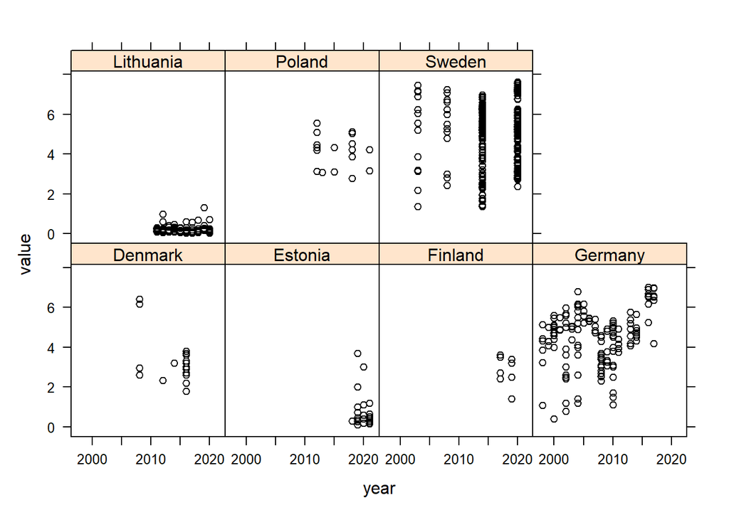

```r
wk <- sediment_data$data %>%
  filter(!is.na(station_name)) %>%
  group_by(station_name) %>%
  filter(any(year >= 2016)) %>%
  ungroup()

wk <- wk %>%
  filter(determinand %in% c("AL", "CORG", "LOIGN")) %>%
  mutate(value = convert.units(value, unit, "%"))

lattice::xyplot(
  value ~ year | country,
  data = subset(wk, determinand == "AL"),
  col = "black",
  scales = list(alternating = FALSE)
)
```

Here are the Lithuanian aluminium measurements on their own. They have been confirmed correct (Nijole, 19 August 2022) but are mostly lower than the values you would find in pure sand (even with a weak digestion method).

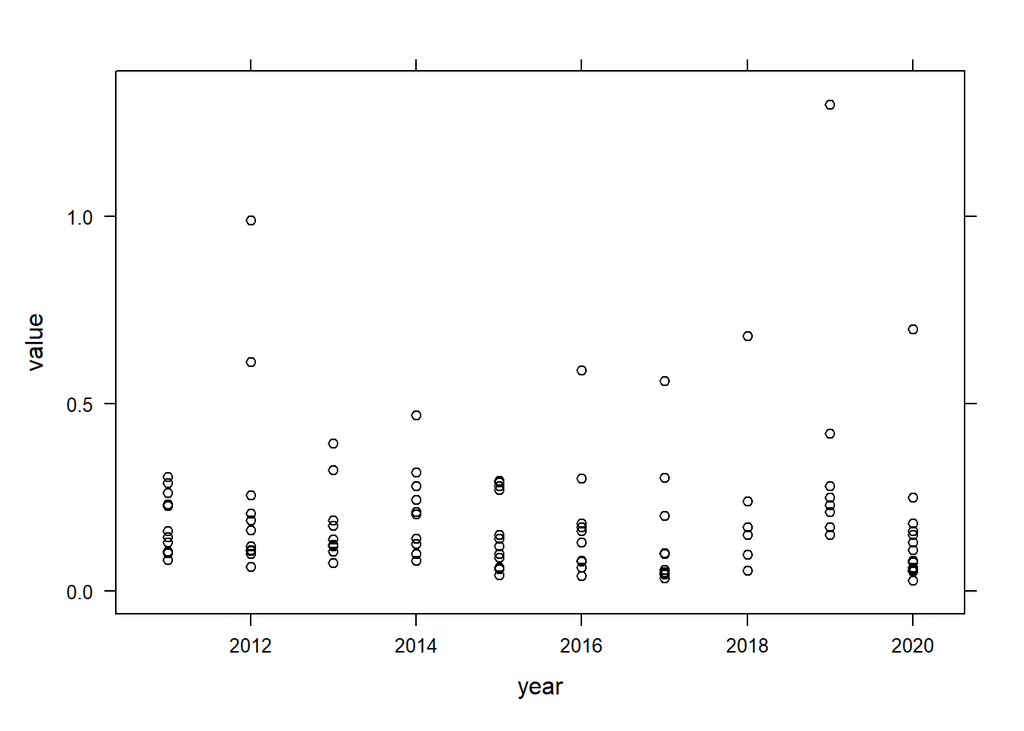

```r
wk1 <- filter(wk, determinand == "AL" & country == "Lithuania")

lattice::xyplot(
  value ~ year,
  data = wk1,
  col = "black",
)
```

Here are the Estonian aluminium measurements. They are low relative to other countries, but not as pronounced as for Lithuania. The corresponding organic carbon measurements are also very low, so they are probably monitoring very sandy sediments without sieving.

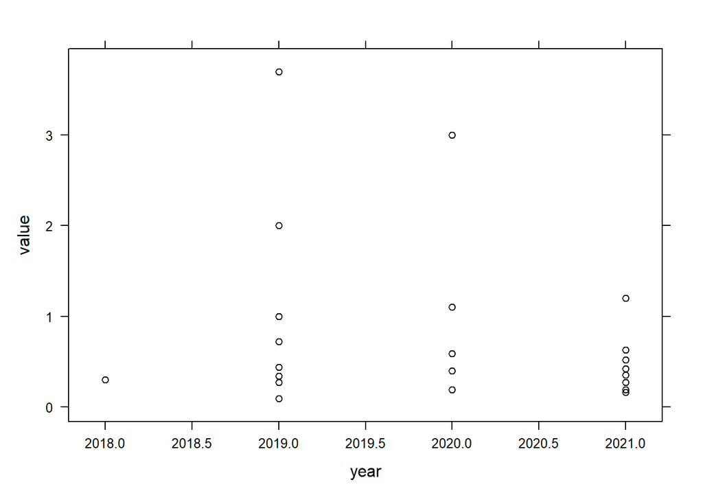

```r
wk1 <- filter(wk, determinand == "AL" & country == "Estonia")

lattice::xyplot(
  value ~ year,
  data = wk1,
  col = "black",
)
```

##### CORG / LOIGN

Here is a plot of the CORG (blue) and LOIGN (purple) concentrations (%) in ‘relevant’ time series by year and country. LOIGN will be used for normalising whenever CORG is not available. Assuming CORG = 0.35 $\times$ LOIGN (Owen, 17 August 2022) then normalising to 5% CORG is equivalent to normalising to 14.3% LOIGN.

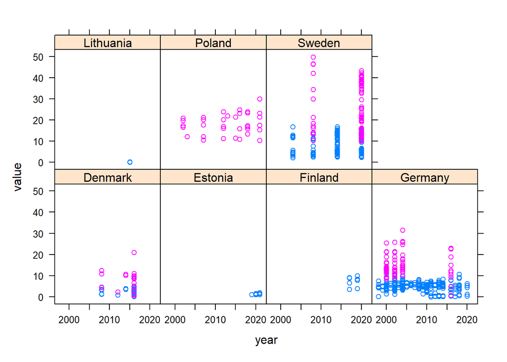

```r
lattice::xyplot(
  value ~ year | country,
  data = subset(wk, determinand %in% c("CORG", "LOIGN")),
  groups = determinand,
  scales = list(alternating = FALSE)
)
```

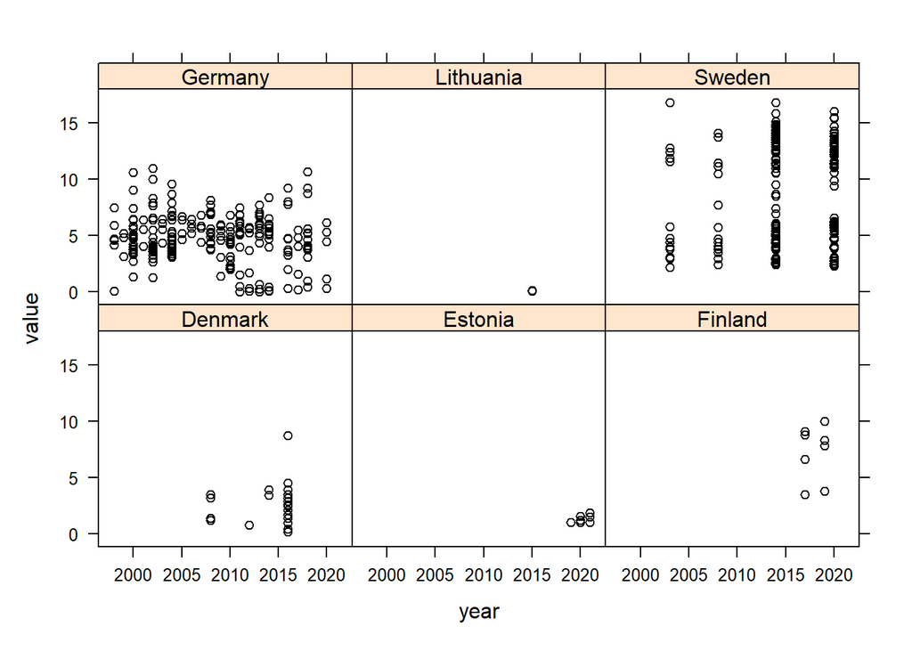

```r
wk <- sediment_data$data %>%
  filter(!is.na(station_name)) %>%
  group_by(station_name) %>%
  filter(any(year >= 2016)) %>%
  ungroup()

wk <- wk %>%
  filter(determinand %in% "CORG") %>%
  mutate(value = convert.units(value, unit, "%"))


lattice::xyplot(
  value ~ year | country,
  data = wk,
  col = "black",
  scales = list(alternating = FALSE)
)
```

##### Sweden - missing CORG

Sweden is missing CORG from sediment samples in 2020 and 2021 in which organic contaminants were measured. Apparently, the samples were damaged / lost before CORG could be measured. For 2021, values are provided by Johan (3 October 2022) based on new samples taken at the same locations. Here are the 2021 samples in the extraction:

```r
wk_data <- sediment_data$data %>%
  filter(
    country == "Sweden",
    year == 2021
  )

with(wk_data, table(sample, determinand))
```

```
         determinand
sample    ANT BD100 BD153 BD154 BDE28 BDE47 BDE99 FLU HBCDA HBCDB HBCDG TBSN+
  3624467   1     1     1     1     1     1     1   1     1     1     1     1
  3624468   1     1     1     1     1     1     1   1     1     1     1     1
  3624469   1     1     1     1     1     1     1   1     1     1     1     1
  3624470   1     1     1     1     1     1     1   1     1     1     1     1
  3624471   1     1     1     1     1     1     1   1     1     1     1     1
  3624472   1     1     1     1     1     1     1   1     1     1     1     1
  3624473   1     1     1     1     1     1     1   1     1     1     1     1
  3624476   1     1     1     1     1     1     1   1     1     1     1     1
```

And here are the values of CORG provided by Johan, which are merged with the main data set.

```r
wk_new <-
  read.csv(
    file.path("data", "example_HELCOM", "SE_missing_CORG_sediment.csv"),
    na.string = ""
  ) %>%
  select(tblSampleID, Value, MUNIT)

wk_new
```

```
  tblSampleID Value MUNIT
1     3624469 12.27     %
2     3624467  5.79     %
3     3624468  6.08     %
4     3624476  2.42     %
5     3624471 12.37     %
6     3624470 11.41     %
7     3624473 14.02     %
8     3624472 11.48     %
```

```r
wk_new <- wk_new %>%
  select(- MUNIT) %>%
  mutate(tblSampleID = as.character(tblSampleID))

wk_data <- filter(wk_data, determinand == "ANT")

wk_data <- left_join(wk_data, wk_new, by = c("sample" = "tblSampleID"))

wk_data <- mutate(
  wk_data,
  indicator = "Supplemental",
  pargroup = "O-MAJ" ,
  determinand = "CORG",
  value = Value,
  unit = "%",
  qflag = NA_character_,
  metoa = NA_character_,
  limit_detection = NA_real_,
  limit_quantification = NA_real_,
  uncertainty = NA_real_,
  methodUncertainty = NA_character_,
  alabo = "NSLS",
  qalink = 0,
  replicate = 1:nrow(wk_data) + max(sediment_data$data$replicate),
  Value = NULL
)

sediment_data$data <- bind_rows(sediment_data$data, wk_data)
```

In 2020, some samples have supporting CORG and others don’t. Here are the number of samples by station, and the corresponding number of CORG measurements. (At some stations there are replicate measurements in the same sample.) The ‘missing’ CORG values are taken to be the median CORG measurement from the station.

```r
wk_data <- filter(
  sediment_data$data,
  country == "Sweden",
  year == 2020
)

wk_data %>%
  group_by(station_name) %>%
  summarise(n_sample = length(unique(sample)), n_CORG = sum(determinand %in% "CORG"), .groups = "drop") %>%
  as.data.frame()
```

```
   station_name n_sample n_CORG
1          SE-1        9      5
2         SE-10        8      5
3         SE-11        8      5
4         SE-12        8      9
5         SE-13        8      5
6         SE-17        9      5
7          SE-2        9      5
8          SE-3        9      5
9          SE-4        9      5
10         SE-5        9      9
11         SE-6        7      5
12         SE-7        8      5
13         SE-8        8      5
14         SE-9        8      5
```

```r
wk_CORG <- filter(wk_data, determinand %in% "CORG")

# identify samples in wk_data with no CORG

wk_data <- wk_data %>%
  filter(!(sample %in% wk_CORG$sample)) %>%
  distinct(sample, .keep_all = TRUE)

wk_CORG <- by(wk_CORG, wk_CORG$station_name, function(x) {
  x <- arrange(x, value)
  id <- floor((nrow(x) + 1) / 2)
  x[id, ]
})

wk_CORG <- do.call(rbind, wk_CORG)

wk_id <- c(
  "indicator", "ges_matrix", "pargroup", "determinand", "basis", "unit",
  "value", "qflag", "limit_detection", "limit_quantification", "uncertainty",
  "methodUncertainty", "alabo", "metoa", "smtyp", "qalink"
)

wk_data[, wk_id] <- wk_CORG[wk_data$station_name, wk_id]

wk_data$replicate <- 1:nrow(wk_data) + max(sediment_data$data$replicate)

sediment_data$data <- bind_rows(sediment_data$data, wk_data)

rm(wk_data, wk_CORG)
```

#### Multiple METCX

There are a few instances of multiple METCX for sediment in the QA file. These are unusual. If they are single methods, new METCX codes should be set up. Unfortunately, the R code can’t currently deal with them, so we have to modify them sensibly. Here are the methods and the determinands they are used for (relevant to the HELCOM assessment)

```r
sediment_data$QA %>%
  filter(
    data_type == "CS",
    determinand %in% c(
      unlist(determinands$Sediment),
      "BDE28", "BDE47", "BDE99", "BD100", "BD153", "BD154", "HBCDA", "HBCDB", "HBCDG"
    ),
    grepl("~", metcx, fixed = TRUE)
  ) %>%
  distinct(metcx, determinand, alabo) %>%
  arrange(metcx, alabo) %>%
  select(metcx, alabo, determinand) %>%
  as.data.frame() %>%
  DT::datatable(options = DT_options, rownames = FALSE)
```

| metcx | alabo | determinand |
| --- | --- | --- |
| ACE~PLE~TOL | LRCN | BD153 |
| ACE~PLE~TOL | LRCN | BD154 |
| ACE~PLE~TOL | LRCN | HBCDA |
| ACE~PLE~TOL | LRCN | HBCDB |
| ACH~PLE | BFGG | ANT |
| ACH~PLE | BFGG | FLU |
| ACH~PLE | GBAH | ANT |
| ACH~PLE | GBAH | FLU |
| ACH~PLE | NOWG | ANT |
| ACH~PLE | NOWG | FLU |

[output cut: 18 more lines]

Fortunately, most of these are for organics, for which METCX isn’t used. So replace e.g. ACH~PLE by ACE etc.

HNO-CM~LMF-A-L is more problematic, because it is for metals and is a combination of a strong and a total digestion method, which doesn’t make sense. Fortunately, it doesn’t matter because the only time series with metals data analysed by this method finished in 2014 (see below). So we can replace this code by HNO-CM without it having any impact on the assessment.

```r
sediment_data$QA <- mutate(
  sediment_data$QA,
  metcx = recode(
    metcx,
    "ACH~PLE" = "ACH",
    "ACE~PLE~TOL" = "ACE",
    "DCM~METH" = "DCM",
    "HAC~METH" = "HAC",
    "HX~SPE-DCM~PLE" = "HX",
    "SOX~TOL" = "SOX"
  )
)

wk_id <- sediment_data$QA %>%
  filter(
    data_type == "CS",
    determinand %in% c("CD", "HG", "CU"),
    metcx == "HNO-CM~LMF-A-L"
  ) %>%
  distinct(alabo, year) %>%
  unite(.id) %>%
  pull(.id)

wk_id <- sediment_data$data %>%
  unite(".id", alabo, year) %>%
  filter(.id %in% wk_id) %>%
  pull(station_code) %>%
  unique()

sediment_data$data %>%
  filter(
    determinand %in% c("CD", "PB", "CU"),
    station_code == 11167
  ) %>%
  select(country, station_code, station_name, alabo, determinand, year) %>%
  arrange(year)
```

```
   country station_code           station_name alabo determinand year
1   Sweden        11167 Edeboviken (2 H) yttre  ALGT          CU 2001
2   Sweden        11167 Edeboviken (2 H) yttre  ALGT          CD 2001
3   Sweden        11167 Edeboviken (2 H) yttre  ALGT          PB 2001
4   Sweden        11167 Edeboviken (2 H) yttre  ALGT          CU 2006
5   Sweden        11167 Edeboviken (2 H) yttre  ALGT          CD 2006
6   Sweden        11167 Edeboviken (2 H) yttre  ALGT          PB 2006
7   Sweden        11167 Edeboviken (2 H) yttre  ALGT          CU 2011
8   Sweden        11167 Edeboviken (2 H) yttre  ALGT          CD 2011
9   Sweden        11167 Edeboviken (2 H) yttre  ALGT          PB 2011
10  Sweden        11167 Edeboviken (2 H) yttre  ALGT          CU 2014
11  Sweden        11167 Edeboviken (2 H) yttre  ALGT          CD 2014
12  Sweden        11167 Edeboviken (2 H) yttre  ALGT          PB 2014
```

```r
sediment_data$QA <- mutate(
  sediment_data$QA,
  metcx = recode(metcx, "HNO-CM~LMF-A-L" = "HNO-CM")
)
```

#### Missing uncertainties LOIGN

Missing uncertainties for all determinands other than LOIGN are imputed using the fixed and relative standard deviations derived for the OSPAR 2022 assessment. Fixed and relative standard deviations for LOIGN need to be estimated from the HELCOM data (because LOIGN was not used in the OSPAR 2022 assessment). Here is a plot of the relative uncertainties for LOIGN that have been reported, by country. (Some very large Danish uncertainties have been omitted - these are probably due to unit errors.)

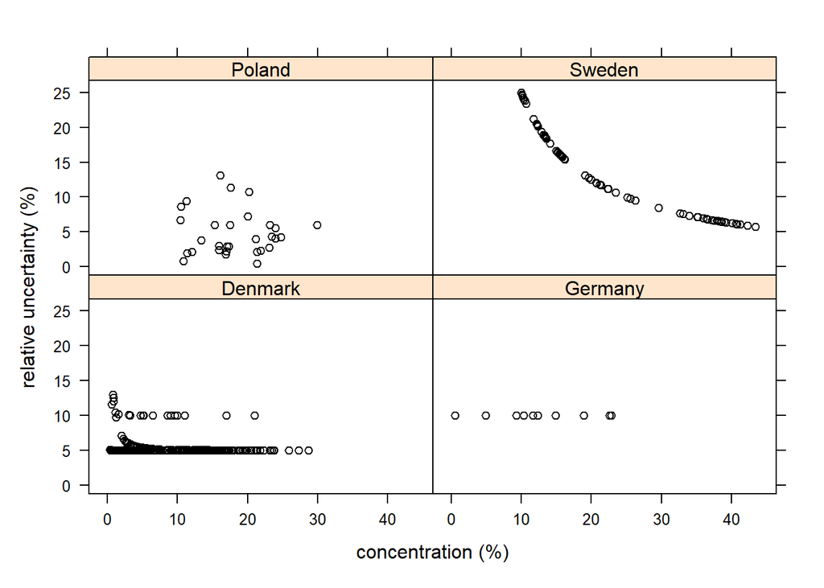

```r
wk <- sediment_data$data %>%
  filter(determinand %in% "LOIGN") %>%
  mutate(
    value = convert.units(value, unit, "%"),
    uncertainty = case_when(
      methodUncertainty == "U2" ~ 100 * (uncertainty / 2) / value,
      methodUncertainty == "SD" ~ 100 * uncertainty / value,
      TRUE                      ~ uncertainty
    ),
    uncertainty = if_else(uncertainty >= 100, NA_real_, uncertainty)
  ) %>%
  drop_na(uncertainty)

xyplot(
  uncertainty ~ value | country,
  data = wk,
  col = "black",
  scales = list(alternating = FALSE),
  ylab = "relative uncertainty (%)",
  xlab = "concentration (%)"
)
```

The relative standard deviations is estimated using the same procedures as used by OSPAR, and gives a value of 0.1 (10%). The constant standard deviation is set to 0 (because there are hardly any less-than measurements on which to base it).

```r
out_relative <- wk %>%
  filter(
    is.na(.data$qflag),
    !is.na(alabo)
  ) %>%
  group_by(.data$determinand, .data$alabo, .data$country) %>%
  summarise(sd_variable = median(.data$uncertainty) / 100, .groups = "drop")

# now the median value across alabos

out_relative <- summarise(out_relative, sd_variable = median(sd_variable))
```

### Biota

#### Data summary

Here is a summary of the submissions for each country, first by determinand and then by year. Some of the less useful supporting data have been omitted for simplicity (as have the four UK records from 1999)

```r
wk <- filter(
  biota_data$data,
  !grepl("TIN", determinand),
  determinand != "IMPF%",
  country != "United Kingdom",
)

wk %>%
  with(table(country, determinand)) %>%
  print(zero.print = ".")
```

```
           determinand
country     %FEMALEPOP   BAP BD100 BD153 BD154 BDE28 BDE47 BDE99 BR-PFOS CB101 CB105 CB110 CB114 CB118
  Denmark            .  1012   124   123   124    88   107   119       .   519   522   294    38   513
  Estonia            .     .    27    27    27    27    27    27       .   210    28     .    28   211
  Finland            .     .   134   134   134   134   134   134       .   749   155   119   107   749
  Germany            .   156   353   314   367   355   358   367       .   569   443     .    14   524
  Latvia             .     .     6     6     6     6     6     6       .     9     6     .     6     9
  Lithuania          .     4    12    12    12    12    12    12       .     .    12     .    12    12
  Poland             .    18   620   620   620   620   620   620       .  1152     .     .     .  1152
  Sweden           298    31  1103  1078   467   470  2011  1997     282  2783   505     .   425  3328
           determinand
country     CB122 CB123 CB126 CB128 CB138 CB138+163 CB141 CB149 CB151 CB153 CB156 CB157 CB167 CB169
  Denmark       .    38    88   425   520         .     .   377   246   521   523   108    38    89
  Estonia       .    28    28     .   211         .     .     .     .   211    28    28    28    28
  Finland      48   107   107    71   748         .    71    48     .   749   155   107   107   107
  Germany       .    14    14    99   569         .     .    98     .   568   445    14    14    14
  Latvia        .     6     6     .     9         .     .     .     .     9     6     6     6     6
  Lithuania     .    12    12     .     .         .     .     .     .     .    12    12    12    12
  Poland        .     .     .     .  1152         .     .     .     .  1152     .     .     .     .
  Sweden        .   425   425     .  2283       503     .     .     .  2785   505   505   505   505
           determinand
country     CB170  CB18 CB180 CB183 CB187 CB189 CB194 CB206 CB209  CB28  CB31  CB33  CB44  CB47  CB49
  Denmark     446     .   520     .   174    38     .     .     6   517   504     .   246     .   246
  Estonia       .     .   208     .     .    28    10     .     .   209     .     .     .     .     .
  Finland     119    71   747    71   119   107    71    71    71   708    48    71     .    71    71
  Germany      24     .   569     .     .    14     .     .     .   559     .     .     .     .     .
  Latvia        .     .     9     .     .     6     .     .     .     8     .     .     .     .     .
  Lithuania     .     .     .     .     .    12     .     .     .     .     .     .     .     .     .
  Poland        .     .  1152     .     .     .     .     .     .  1152     .     .     .     .     .
  Sweden        .     .  2785     .     .   425     .     .     .  2663     .     .     .     .     .
           determinand
country      CB51  CB52  CB60  CB66  CB74  CB77  CB81  CB99    CD CDD1N CDD4X CDD6P CDD6X CDD9X  CDDO
  Denmark       .   519     .     .     .    88    37   247  1913   105   106   105   106   105    80
  Estonia       .   211     .     .     .    28    28     .    98    26    26    26    26    26    26
  Finland      48   730    48   119    71   107   107    71   780   109   109   109   109   109   109
  Germany       .   559     .     .     .    14    14     .   743    14    14    14    14    14    14
  Latvia        .     9     .     .     .     6     6     .   262     .     .     .     .     .     6
  Lithuania     .     .     .     .     .    12    12     .    96    12    12    12    12    10     7
  Poland        .  1152     .     .     .     .     .     .  1419     .     .     .     .     .     .
  Sweden        .  2674     .     .     .   505   425     .  2835   585   585   585   585   585   585
```

[output cut: 25 more lines]

```
  Germany       .        .  2151      .    14   770     .    12   1311     .     .       .
  Latvia        .        .   267      .     6   170     .     4      .     .     .       .
  Lithuania     .       31    17      .    12    96     .    12      .     .     .      18
  Poland        .      909  2538      .     .  1411     .   532     54     .     .       .
  Sweden        .        . 12673    282     2  2834     .   241      .     .     .       .
           determinand
country     SUM_PCDD_PCDF SUM_PCDD_PCDF_PCB  TCDD   VDS  VDSI
  Denmark               .                 .   105  3273    76
  Estonia               .                 .    26     .     .
  Finland               .                 .   109     .     .
  Germany               .                 .    14     .     .
  Latvia                .                 .     6     .     .
  Lithuania            32                32     7     .     .
  Poland                .                 .     .     .     .
  Sweden                .                 .   585  8942   298
```

```r
wk %>%
  with(table(country, year)) %>%
  print(zero.print = ".")
```

```
           year
country     1979 1981 1982 1983 1984 1985 1986 1987 1988 1989 1990 1991 1992 1993 1995 1996 1997 1998
  Denmark      .    .    .    .    .    .    .    .    .    .    .    .    .    .    .    .  300 1232
  Estonia      .    .    .    .    .    .    .    .    .    .    .    .    .    .    .    .    .    .
  Finland     13   14   14   44   39   49   59   60   73  163   92  108   81  108   79   81   28  905
  Germany      .    .    .    .    .    .    .    .    .    .    .    .    .    .    .    .    .  110
  Latvia       .    .    .    .    .    .    .    .    .    .    .    .    .    .    .    .    .    .
  Lithuania    .    .    .    .    .    .    .    .    .    .    .    .    .    .    .    .    .    .
  Poland       .    .    .    .    .    .    .    .    .    .    .    .    .    .    .    .    .  284
  Sweden       .    .    .    .    .    .    .    .    .    .    .    .    .    .    .    . 1663 2049
           year
country     1999 2000 2001 2002 2003 2004 2005 2006 2007 2008 2009 2010 2011 2012 2013 2014 2015 2016
  Denmark    893  980 1646 1475 1624 1331  993 1012 1034 1540 2442 1306 3732 1789 3208 1546  585  793
  Estonia      .    .    .    .    .    4  108  126   84   14    .    .  276  368  296  246  247    .
  Finland    909  234  369  450  142  144  571  576  557  320  317  371 1019 1382  439 1451  366 1683
  Germany    209  211   81   96  110    .  159  156  839  545 1372 1237 1118 1063 1623 1526 1602  602
  Latvia       .    2   37  120    .    .    .   44   67    .    .    .  143   91  149   76   45   85
  Lithuania    .    .    .    .    .    .    .    .    8    .   12   21   37   73   58   40  246  353
  Poland     241  315  318  307  280  785  785  785  525  525  525  525  525 1226 1428 1700 1588 1600
  Sweden    2235 2148 2413 2180 2720 2446 2439 2193 2404 3544 5325 4670 5447 5395 5192 4562 1492 4559
           year
country     2017 2018 2019 2020 2021
  Denmark   1132 1107  965 1151  603
  Estonia     54  235  303  400  336
  Finland     47  410 1269 1023  743
  Germany    915  500  446  859  415
  Latvia     160  164  125  368    .
  Lithuania    8   40   24   32    .
  Poland    1590 1596 1639 1824 1898
  Sweden    4892 5227 4920 4635  972
```

#### Duplicate records

##### Finland - PFOS, FATWT%

Some PFOS and FATWT% records from Finland in 2014 and 2015 appear to be duplicated (see below). Only the first are retained. (There is one set of FATWT% records which differ, and these are both kept for now - I wonder whether one of these should actually be MU.)

```r
wk <- biota_data$data %>%
  filter(
    country == "Finland",
    year >= 2014
  ) %>%
  group_by(sub.sample, determinand, matrix) %>%
  filter(n() >= 2) %>%
  ungroup()

wk %>%
  select(country, year, station_name, sub.sample, determinand, matrix, replicate, value) %>%
  arrange(sub.sample, determinand, replicate) %>%
  as.data.frame() %>%
  DT::datatable(options = DT_options, rownames = FALSE)
```

| country | year | station_name | sub.sample | determinand | matrix | replicate | value |
| --- | --- | --- | --- | --- | --- | --- | --- |
| Finland | 2014 | Kellonlahti | 3796797 | FATWT% | MU | 50619431 | 0.62 |
| Finland | 2014 | Kellonlahti | 3796797 | FATWT% | MU | 50619432 | 0.62 |
| Finland | 2014 | Kellonlahti | 3796797 | PFOS | MU | 50619122 | 1.37 |
| Finland | 2014 | Kellonlahti | 3796797 | PFOS | MU | 50619123 | 1.37 |
| Finland | 2014 | Kellonlahti | 3796798 | PFOS | LI | 50619131 | 12.8 |
| Finland | 2014 | Kellonlahti | 3796798 | PFOS | LI | 50619132 | 12.8 |
| Finland | 2014 | Kellonlahti | 3796799 | FATWT% | MU&amp;EP | 50619433 | 1.1 |
| Finland | 2014 | Kellonlahti | 3796799 | FATWT% | MU&amp;EP | 50619434 | 1.1 |
| Finland | 2014 | Kellonlahti | 3796799 | PFOS | MU&amp;EP | 50619129 | 2.42 |
| Finland | 2014 | Kellonlahti | 3796799 | PFOS | MU&amp;EP | 50619130 | 2.42 |

[output cut: 68 more lines]

```r
wk_rep <- wk$replicate

wk_keep <- wk %>%
  select(sub.sample, matrix, determinand, replicate, value) %>%
  arrange(replicate) %>%
  distinct(sub.sample, matrix, determinand, value, .keep_all = TRUE) %>%
  pull(replicate)

wk_drop <- setdiff(wk_rep, wk_keep)

biota_data$data <- filter(
  biota_data$data,
  !replicate %in% wk_drop
)
```

##### Sweden - dioxins

```r
relevant_biota <- get_relevant_biota()

wk <- relevant_biota %>%
  filter(pargroup %in% c("OC-DX", "O-BR", "OC-CB")) %>%
  group_by(sub.sample, matrix, determinand) %>%
  filter(all(c("L", "W") %in% basis)) %>%
  ungroup() %>%
  arrange(country, station_name, year, determinand, sub.sample, basis)

wk %>%
  mutate(across(where(is.character), factor)) %>%
  summary()
```

```
                          indicator      ges_matrix     country           mprog       rlabo
 dl-PCBs and dioxins and furans:2432   Primary:2432   Sweden:2432   CEMP~COMB: 128   SERI:2432
                                                                    COMB     :2304





                    region        l3area        l4area                 submitted.station    sd_code
 Bothnian Sea          :576   6      :448   SEA-007:384   Ängskärsklubb         : 256    6140   : 256
 Bornholm Basin        :384   2      :384   SWE-016:384   Utlängan              : 256    6226   : 256
 Bothnian Bay          :384   SEA-007:384   SEA-010:256   Holmöarna             : 192    5809   : 192
 Western Gotland Basin :320   4      :256   SWE-022:256   Abbekås               : 128    11188  : 128
 Northern Baltic Proper:256   SEA-010:256   SWE-021:192   Bothnian Sea off shore: 128    11189  : 128
 The Quark             :256   9      :128   SEA-001:128   Byxelkrok             : 128    5803   : 128
 (Other)               :256   (Other):576   (Other):832   (Other)               :1344    (Other):1344
                   sd_name      station_code                  station_name       year
 Ängskärsklubb         : 256   6140   : 256   Ängskärsklubb         : 256   Min.   :2009
 Utlängan              : 256   6226   : 256   Utlängan              : 256   1st Qu.:2009
 Holmöarna             : 192   5809   : 192   Holmöarna             : 192   Median :2009
 Abbekås               : 128   11188  : 128   Abbekås               : 128   Mean   :2009
 Bothnian Sea off shore: 128   11189  : 128   Bothnian Sea off shore: 128   3rd Qu.:2010
 Byxelkrok             : 128   5803   : 128   Byxelkrok             : 128   Max.   :2010
 (Other)               :1344   (Other):1344   (Other)               :1344
         date         latitude       longitude     purpm     finfl                   species
 11/05/2009: 128   Min.   :55.32   Min.   :11.83   T:2432   NA's:2432   Clupea harengus  :2240
 12/10/2010: 128   1st Qu.:57.22   1st Qu.:15.78                        Perca fluviatilis: 192
 01/10/2010:  64   Median :60.05   Median :18.16
 04/10/2010:  64   Mean   :60.13   Mean   :18.14
 06/09/2010:  64   3rd Qu.:63.53   3rd Qu.:20.50
 07/08/2009:  64   Max.   :65.76   Max.   :22.88
 (Other)   :1920
   sex           noinp        pargroup     determinand   matrix    basis       unit
 F   :1280   Min.   : 7.00   OC-DX:2432   CDD1N  : 152   MU:2432   L:1216   ng/kg:  76
 M   :1120   1st Qu.:12.00                CDD4X  : 152             W:1216   pg/g :2356
 NA's:  32   Median :12.00                CDD6P  : 152
             Mean   :11.78                CDD6X  : 152
             3rd Qu.:12.00                CDD9X  : 152
             Max.   :12.00                CDDO   : 152
                                          (Other):1520
```

[output cut: 9 more lines]

```
 NA's:2432         UMSC:2432   GC-MS:2432   NA's:2432   NA's:2432   34649  :  64   1022010229:  32
                                                                    34650  :  64   1070810719:  32
                                                                    34651  :  64   1072010731:  32
                                                                    34652  :  64   1098710998:  32
                                                                    34653  :  64   1099911010:  32
                                                                    34654  :  64   1125311259:  32
                                                                    (Other):2048   (Other)   :2240
     qalink         replicate          sub.sample       sample       tblspotid          upload
 Min.   :516368   Min.   :47976502   3741770:  32   2112871:  64   Min.   :367894   Min.   :10335
 1st Qu.:516375   1st Qu.:47984157   3741771:  32   2112872:  64   1st Qu.:367929   1st Qu.:10335
 Median :516383   Median :47985670   3741784:  32   2112873:  64   Median :367950   Median :10335
 Mean   :516416   Mean   :47988683   3741785:  32   2112875:  64   Mean   :367952   Mean   :10335
 3rd Qu.:516458   3rd Qu.:47994241   3741798:  32   2112876:  64   3rd Qu.:367982   3rd Qu.:10336
 Max.   :516466   Max.   :47996074   3741799:  32   2112877:  64   Max.   :368010   Max.   :10336
                                     (Other):2240   (Other):2048
```

```r
wk_id <- wk %>%
  filter(basis == "W") %>%
  pull(replicate)

biota_data$data <- filter(
  biota_data$data,
  !replicate %in% wk_id
)
```

##### Germany - FATWT%

Some FATWT% records from Germany appear to be duplicated (see below). One set of uncertainty measurements are unusually small, so accept the other (where either uncertainty is reported as a percentage, or where the U2 is ten percent of the value).

```r
wk <- biota_data$data %>%
  filter(
    country == "Germany",
    determinand %in% "FATWT%"
  ) %>%
  group_by(sub.sample, determinand, matrix) %>%
  filter(n() >= 2) %>%
  ungroup()

wk %>%
  select(year, station_name, sub.sample, determinand, matrix,
         replicate, value, uncertainty, methodUncertainty) %>%
  arrange(year, sub.sample, determinand, replicate) %>%
  as.data.frame() %>%
  DT::datatable(options = DT_options, rownames = FALSE)
```

| year | station_name | sub.sample | determinand | matrix | replicate | value | uncertainty | methodUncertainty |
| --- | --- | --- | --- | --- | --- | --- | --- | --- |
| 2018 | OMMVWB3 | 3958871 | FATWT% | LI | 62740845 | 17 | 0.289 | U2 |
| 2018 | OMMVWB3 | 3958871 | FATWT% | LI | 62740850 | 17 | 15 | % |
| 2018 | OMMVWB3 | 3958872 | FATWT% | MU | 62740858 | 1.1 | 0.00121 | U2 |
| 2018 | OMMVWB3 | 3958872 | FATWT% | MU | 62740859 | 1.1 | 15 | % |
| 2019 | OMMVMYT6 | 3958468 | FATWT% | SB | 62736572 | 0.7 | 0.00049 | U2 |
| 2019 | OMMVMYT6 | 3958468 | FATWT% | SB | 62736573 | 0.7 | 0.07 | U2 |
| 2019 | OMMVMYT5 | 3958469 | FATWT% | SB | 62736562 | 1 | 0.001 | U2 |
| 2019 | OMMVMYT5 | 3958469 | FATWT% | SB | 62736563 | 1 | 0.1 | U2 |
| 2019 | OMMVKB90 | 3958470 | FATWT% | LI | 62736568 | 3.8 | 0.01444 | U2 |
| 2019 | OMMVKB90 | 3958470 | FATWT% | LI | 62736569 | 3.8 | 15 | % |

[output cut: 48 more lines]

```r
wk_rep <- wk$replicate

wk_keep <- wk %>%
  filter(
    methodUncertainty == "%" |
      100 * uncertainty / value > 5
  ) %>%
  pull(replicate)

stopifnot(2 * length(wk_keep) == length(wk_rep))

wk_drop <- setdiff(wk_rep, wk_keep)

biota_data$data <- filter(
  biota_data$data,
  !replicate %in% wk_drop
)
```

#### PCBs and dioxins

Here’s a summary of the determinands submitted for PCBs, dioxins and furans.

```r
wk <- biota_data$data %>%
  filter(
    !is.na(station_name),
    pargroup %in% c("OC-CB", "OC-DX", "OC-DX~OC-CB")
  )

table(wk$determinand)
```

```
            CB101             CB105             CB110             CB114             CB118
             5963              1643               411               605              6469
            CB122             CB123             CB126             CB128             CB138
               48               605               655               593              5464
        CB138+163             CB141             CB149             CB151             CB153
              503                69               523               246              5967
            CB156             CB157             CB167             CB169             CB170
             1646               755               685               736               587
             CB18             CB180             CB183             CB187             CB189
               69              5962                69               291               605
            CB194             CB206             CB209              CB28              CB31
               76                69                75              5788               545
             CB33              CB44              CB47              CB49              CB51
               69               246                69               315                48
             CB52              CB60              CB66              CB74              CB77
             5826                48               117                69               735
             CB81              CB99             CDD1N             CDD4X             CDD6P
              604               316               750               751               750
            CDD6X             CDD9X              CDDO             CDDSN             CDDSP
              751               748               726                 6                 6
            CDDST             CDDSX             CDF2N             CDF2T             CDF4X
                6                 6               830               756               750
            CDF6P             CDF6X             CDF9P             CDF9X             CDFDN
              749               751               750               750               247
             CDFO             CDFP2             CDFSN             CDFSP             CDFST
              605               663                 6                 6                 6
            CDFSX             CDFX1              OCDF               PCB               SCB
                6               666               148                28                10
             SCB7           SUM_PCB     SUM_PCDD_PCDF SUM_PCDD_PCDF_PCB              TCDD
              181                18                32                32               751
```

There are some summed values which need to be accounted for. Here they are by year.

```r
wk_id <- c("PCB", "SCB", "SCB7", "SUM_PCB", "SUM_PCDD_PCDF", "SUM_PCDD_PCDF_PCB")

wk %>%
  filter(determinand %in% wk_id) %>%
  with(table(determinand, year)) %>%
  print(zero.print = ".")
```

```
                   year
determinand         1979 1981 1982 1983 1984 1985 1986 1987 1988 1989 1990 1991 1992 1993 1995 1996
  PCB                  2    2    2    4    6    4    4    4    .    .    .    .    .    .    .    .
  SCB                  .    .    .    .    .    .    .    .    .    .    .    .    .    .    .    .
  SCB7                 .    .    .    .    .    .    .    .    6   15    8    8    6    8    6    6
  SUM_PCB              .    .    .    .    .    .    .    .    .    .    .    .    .    .    .    .
  SUM_PCDD_PCDF        .    .    .    .    .    .    .    .    .    .    .    .    .    .    .    .
  SUM_PCDD_PCDF_PCB    .    .    .    .    .    .    .    .    .    .    .    .    .    .    .    .
                   year
determinand         1998 1999 2006 2010 2011 2012 2013 2014 2015
  PCB                  .    .    .    .    .    .    .    .    .
  SCB                  .    .   10    .    .    .    .    .    .
  SCB7                60   58    .    .    .    .    .    .    .
  SUM_PCB              .    .    .    .    .    5    4    4    5
  SUM_PCDD_PCDF        .    .    .    5    5    8    5    4    5
  SUM_PCDD_PCDF_PCB    .    .    .    5    5    8    5    4    5
```

- PCB is ambiguous, deprecated and old
- SCB is ambiguous, deprecated and only occurs in 2006
- SCB7 is not relevant because it combines non-planar CBs with the dioxin-like CB118 (and is also pretty old)
- SUM_PCB, SUM_PCDD_PCDF and SUM_PCDD_PCDF_PCB are, I think, Lithuanian food safety data which we made special arrangements for last time; however, there are no data in the last six monitoring years for these combinations, nor for individual congeners at the same stations; these data therefore fall out of the assessment

The assessment code doesn’t recognise some of these ad-hoc determinands without modification, so it is a lot easier to get rid of them here.

```r
wk_check <- wk %>%
  group_by(station_name) %>%
  filter(any(year >= 2016)) %>%
  ungroup()

wk_id2 <- c("SUM_PCB", "SUM_PCDD_PCDF", "SUM_PCDD_PCDF_PCB")

if (any(wk_id2 %in% wk_check$determinand)) {
  stop("have current summed Lithuanian data")
}

biota_data$data <- filter(
  biota_data$data,
  !determinand %in% wk_id
)
```

#### Replicate measurements

##### Sweden - PCBs

Some Swedish PCBs (predominantly CB118) have been measured twice in the same individual, I presume once for the standard set of PCB reporting and once for dioxin reporting. Here are the number of measurements affected, with the corresponding analytical laboratory (restricted to relevant stations where there are data in the last six monitoring years).

```r
relevant_biota <- get_relevant_biota()

wk <- relevant_biota %>%
  filter(
    pargroup %in% "OC-CB",
    country == "Sweden"
  ) %>%
  group_by(sub.sample, matrix, determinand) %>%
  filter(n() >= 2) %>%
  ungroup() %>%
  as.data.frame()

wk %>%
  with(table(determinand, alabo))
```

```
           alabo
determinand NSLS SLMV UMSC
      CB114    0    0    2
      CB118  247   32  280
      CB123    0    0    2
      CB126    0    0    2
      CB189    0    0    2
      CB81     0    0    2
```

Here are the analtyical laboratories that also measured dioxins in these sub-samples.

```r
wk_id <- wk$sub.sample

relevant_biota %>%
  filter(
    sub.sample %in% wk_id,
    pargroup == "OC-DX"
  ) %>%
  with(table(determinand, alabo))
```

```
           alabo
determinand UMSC
      CDD1N  279
      CDD4X  279
      CDD6P  279
      CDD6X  279
      CDD9X  279
      CDDO   279
      CDF2N  279
      CDF2T  279
      CDF4X  279
      CDF6P  279
      CDF6X  279
      CDF9P  279
      CDF9X  279
      CDFDN  101
      CDFO   279
      CDFP2  280
      CDFX1  280
      TCDD   280
```

Sensible decision seems to be to retain the CB118 measurements from analytical laboratory UMSC, since they are part of the same analysis suite. This leaves two replicates for six PCBs in a single sub.sample. These appear to be genuine replicates. Will leave them both in, and the code will select one of them for the analysis.

```r
wk_id <- wk %>%
  filter(!alabo %in% "UMSC") %>%
  pull(replicate)

biota_data$data <- filter(
  biota_data$data,
  !replicate %in% wk_id
)

get_relevant_biota() %>%
  filter(
    pargroup %in% "OC-CB",
    country == "Sweden"
  ) %>%
  group_by(sub.sample, matrix, determinand) %>%
  filter(n() >= 2) %>%
  ungroup() %>%
  as.data.frame() %>%
  DT::datatable(options = DT_options, rownames = FALSE)
```

| indicator | ges_matrix | country | mprog | rlabo | region | l3area | l4area | submitted.station | sd_code | sd_name | station_code | station_name | year | date | latitude | longitude | purpm | finfl | species | sex | noinp | pargroup | determinand | matrix | basis | unit | value | qflag | vflag | … |
| --- | --- | --- | --- | --- | --- | --- | --- | --- | --- | --- | --- | --- | --- | --- | --- | --- | --- | --- | --- | --- | --- | --- | --- | --- | --- | --- | --- | --- | --- | --- |
| Non dl-PCBs (PCBs) | Primary | Sweden | COMB | SERI | Bornholm Basin | SEA-007 | SEA-007 | Utlängan | 6140 | Utlängan | 6140 | Utlängan | 2012 | 04/06/2012 | 55.9491 | 15.781 | T |  | Clupea harengus | M | 12 | OC-CB | CB81 | MU | L | pg/g | 14 |  |  | … |
| Non dl-PCBs (PCBs) | Primary | Sweden | COMB | SERI | Bornholm Basin | SEA-007 | SEA-007 | Utlängan | 6140 | Utlängan | 6140 | Utlängan | 2012 | 04/06/2012 | 55.9491 | 15.781 | T |  | Clupea harengus | M | 12 | OC-CB | CB81 | MU | L | pg/g | 10 |  |  | … |
| Non dl-PCBs (PCBs) | Primary | Sweden | COMB | SERI | Bornholm Basin | SEA-007 | SEA-007 | Utlängan | 6140 | Utlängan | 6140 | Utlängan | 2012 | 04/06/2012 | 55.9491 | 15.781 | T |  | Clupea harengus | M | 12 | OC-CB | CB189 | MU | L | pg/g | 430 |  |  | … |
| Non dl-PCBs (PCBs) | Primary | Sweden | COMB | SERI | Bornholm Basin | SEA-007 | SEA-007 | Utlängan | 6140 | Utlängan | 6140 | Utlängan | 2012 | 04/06/2012 | 55.9491 | 15.781 | T |  | Clupea harengus | M | 12 | OC-CB | CB189 | MU | L | pg/g | 310 |  |  | … |
| Non dl-PCBs (PCBs) | Primary | Sweden | COMB | SERI | Bornholm Basin | SEA-007 | SEA-007 | Utlängan | 6140 | Utlängan | 6140 | Utlängan | 2012 | 04/06/2012 | 55.9491 | 15.781 | T |  | Clupea harengus | M | 12 | OC-CB | CB123 | MU | L | pg/g | 350 |  |  | … |
| Non dl-PCBs (PCBs) | Primary | Sweden | COMB | SERI | Bornholm Basin | SEA-007 | SEA-007 | Utlängan | 6140 | Utlängan | 6140 | Utlängan | 2012 | 04/06/2012 | 55.9491 | 15.781 | T |  | Clupea harengus | M | 12 | OC-CB | CB123 | MU | L | pg/g | 190 |  |  | … |
| Non dl-PCBs (PCBs) | Primary | Sweden | COMB | SERI | Bornholm Basin | SEA-007 | SEA-007 | Utlängan | 6140 | Utlängan | 6140 | Utlängan | 2012 | 04/06/2012 | 55.9491 | 15.781 | T |  | Clupea harengus | M | 12 | OC-CB | CB126 | MU | L | pg/g | 250 |  |  | … |
| Non dl-PCBs (PCBs) | Primary | Sweden | COMB | SERI | Bornholm Basin | SEA-007 | SEA-007 | Utlängan | 6140 | Utlängan | 6140 | Utlängan | 2012 | 04/06/2012 | 55.9491 | 15.781 | T |  | Clupea harengus | M | 12 | OC-CB | CB126 | MU | L | pg/g | 150 |  |  | … |
| Non dl-PCBs (PCBs) | Primary | Sweden | COMB | SERI | Bornholm Basin | SEA-007 | SEA-007 | Utlängan | 6140 | Utlängan | 6140 | Utlängan | 2012 | 04/06/2012 | 55.9491 | 15.781 | T |  | Clupea harengus | M | 12 | OC-CB | CB114 | MU | L | pg/g | 550 |  |  | … |
| Non dl-PCBs (PCBs) | Primary | Sweden | COMB | SERI | Bornholm Basin | SEA-007 | SEA-007 | Utlängan | 6140 | Utlängan | 6140 | Utlängan | 2012 | 04/06/2012 | 55.9491 | 15.781 | T |  | Clupea harengus | M | 12 | OC-CB | CB114 | MU | L | pg/g | 410 |  |  | … |

[output cut: 2 more lines]

#### Poland PCB 2014 data

The following plot shows concentrations of CB153 at each station over time. All measurements are in fish muscle and units are ug/kg ww. The species varies between stations, but is consistent within stations. There are some strange things going on here, but the results from 2014 (red) are particularly strange and are deleted (as are all the other PCB data for that year for consistency.)

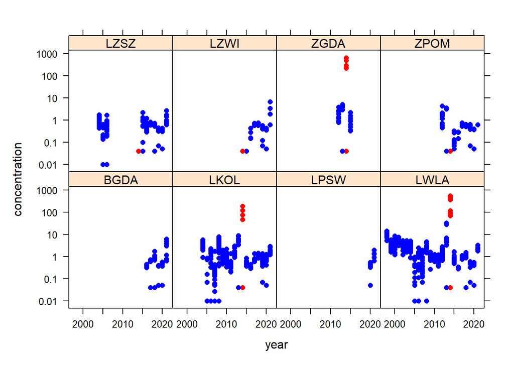

```r
biota_data$data <- mutate(
  biota_data$data,
  .id = country == "Poland" & pargroup == "OC-CB"
)

wk_data <- biota_data$data %>%
  filter(.id & determinand == "CB153") %>%
  mutate(concentration = convert.units(value, unit, "ug/kg"))

stopifnot(
  wk_data$matrix == "MU",
  wk_data$basis == "W"
)

xyplot(
  concentration ~ year | station_name,
  data = wk_data,
  scales = list(alternating = FALSE, y = list(log = TRUE, equispaced.log = FALSE)),
  panel = function(x, y, subscripts) {
    col = if_else(wk_data$year[subscripts] == 2014, "red", "blue")
    lpoints(x, y, pch = 16, col = col)
  }
)
```

Here is what the data look like without the 2014 values. Many less-than values are implausibly low relative to the bulk of the data (see LWLA and LKOL in 2013, and many stations between 2005 and 2008), and the data could do with further scrutiny. The other PCBs might exhibit similar features, but this hasn’t been investigated.

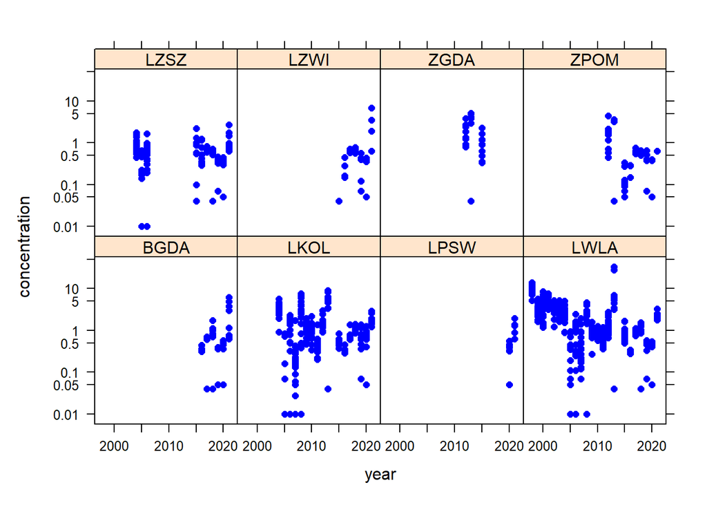

```r
biota_data$data <- filter(
  biota_data$data,
  !(.id & year == 2014)
)

wk_data <- biota_data$data %>%
  filter(.id & determinand == "CB153") %>%
  mutate(concentration = convert.units(value, unit, "ug/kg"))

biota_data$data$'.id' <- NULL

xyplot(
  concentration ~ year | station_name,
  data = wk_data,
  scales = list(alternating = FALSE, y = list(log = TRUE, equispaced.log = FALSE)),
  panel = function(x, y, subscripts) {
    col = if_else(wk_data$year[subscripts] == 2014, "red", "blue")
    lpoints(x, y, pch = 16, col = col)
  }
)
```

#### Strange qflags

The following data from relevant stations (with data in the last six years) have qflag = “>”, which is unusual. The German data appear to be well above the limits of detection, so the “>” has been removed. The Swedish data appear to be values below the limit of detection and have been replaced with qflag = “D”.

```r
get_relevant_biota() %>%
  filter(grepl(">", qflag)) %>%
  select(country, year, determinand, value, qflag, limit_detection, limit_quantification) %>%
  arrange(country, year, determinand) %>%
  as.data.frame() %>%
  DT::datatable(options = DT_options, rownames = FALSE)
```

| country | year | determinand | value | qflag | limit_detection | limit_quantification |
| --- | --- | --- | --- | --- | --- | --- |
| Germany | 2010 | CB138 | 0.7462 | &gt; | 0.0826667 | 0.248 |
| Germany | 2010 | CB153 | 1.3633 | &gt; | 0.0906667 | 0.272 |
| Germany | 2010 | CB180 | 0.2017 | &gt; | 0.0326667 | 0.098 |
| Germany | 2010 | CD | 169.5 | &gt; | 0.333333 | 1 |
| Germany | 2010 | DRYWT% | 42.7 | &gt; |  |  |
| Germany | 2010 | DRYWT% | 19.8333 | &gt; |  |  |
| Germany | 2010 | EXLIP% | 3.0833 | &gt; |  |  |
| Germany | 2010 | HG | 139.4 | &gt; | 0.786667 | 2.36 |
| Germany | 2010 | PB | 14.4 | &gt; | 0.3333 | 1 |
| Germany | 2010 | PB | 46.65 | &gt; | 0.3333 | 1 |

[output cut: 79 more lines]

```r
biota_data$data <- mutate(
  biota_data$data,
  .id = grepl(">", qflag),
  qflag = if_else(.id & country == "Germany", NA_character_, qflag),
  qflag = if_else(.id & country == "Sweden", "D", qflag),
  .id = NULL
)
```

#### Matrix MU&EP

Here’s a summary of matrices and species for ‘relevant’ stations (with data in the last six monitoring years).

```r
relevant_biota <- get_relevant_biota()

relevant_biota %>%
  with(table(species, matrix)) %>%
  print(zero.print = ".")
```

```
                    matrix
species                 BI    LI    MU MU&EP   POP    SB    SH    WO
  Buccinum undatum       .     .     .     .     .  2400     .     9
  Clupea harengus       39  9399 59324     .     .     .     .  4443
  Gadus morhua         275  7060  1066     .     .     .     .   840
  Hinia reticulata       .     .     .     .     .   684     .     .
  Limanda limanda      231  2307   279     .     .     .     .   501
  Limecola balthica      .     .     .     .     .    12     .     .
  Littorina littorea     .     .     .     .     .   379     .     .
  Macoma balthica        .     .     .     .     .    26     .     .
  Mytilus edulis         .     .     .     .     .  7191   925   147
  Neptunea antiqua       .     .     .     .     .   443     .     6
  Perca fluviatilis     16  2421 12190  2423     .     .     .  1253
  Peringia ulvae         .     .     .     .    94  6491  6055     .
  Platichthys flesus   338  4964  5923     .     .     .     .   907
  Zoarces viviparus      .   858  4599     .     .     .     .   269
```

There are no contaminant data in BI, POP, SH or WO, so we can ignore these for the current discussion.

```r
relevant_biota %>%
  filter(matrix %in% c("BI", "POP", "SH", "WO")) %>%
  with(table(determinand, matrix)) %>%
  print(zero.print = ".")
```

```
            matrix
determinand    BI  POP   SH   WO
  %FEMALEPOP    .   94    .    .
  LNMEA         .    . 6980 8360
  PYR1OH      899    .    .    .
  VDSI          .    .    .   15
```

Thus, all contaminant data are in MU and LI (fish) or SB (shellfish) apart from some measurements in MU&EP. These are all in Perch from Finland where there also MU measurements. These need to be teased apart. Here’s a summary of the number of records in perch from Finland by matrix and year.

```r
wk <- relevant_biota %>%
  filter(
    country == "Finland",
    species == "Perca fluviatilis"
  )

wk %>%
  with(table(matrix, year)) %>%
  print(zero.print = ".")
```

```
       year
matrix  2011 2012 2014 2015 2016 2019 2020 2021
  LI       .    .    2    3    4    8   12   10
  MU      51  321    9   26   40   89   63   10
  MU&EP    .    .   12  209  595  632  540  435
```

Muscle and skin measurements all start in 2014. Here are the matrices for CD, HG, PB, PFOS and everything else by year.

```r
wk %>%
  filter(determinand != "FATWT%") %>%
  mutate(
    determinand = if_else(
      determinand %in% c("CD", "PB", "HG", "PFOS"),
      determinand,
      "other"
    )
  ) %>%
  with(table(matrix, year, determinand)) %>%
  print(zero.print = ".")
```

```
, , determinand = CD

       year
matrix  2011 2012 2014 2015 2016 2019 2020 2021
  LI       .    .    .    .    2    4    6    5
  MU       .    .    .    .    .    .    .    .
  MU&EP    .    .    .    .    .    1    .    .

, , determinand = HG

       year
matrix  2011 2012 2014 2015 2016 2019 2020 2021
  LI       .    .    .    .    .    .    .    .
  MU      15   55    5   20   40   89   63   10
  MU&EP    .    .    .    .    .    .    .    .

, , determinand = other

       year
matrix  2011 2012 2014 2015 2016 2019 2020 2021
  LI       .    .    .    .    .    .    .    .
  MU      34  248    .    .    .    .    .    .
  MU&EP    .    .    6  192  575  610  528  425

, , determinand = PB

       year
matrix  2011 2012 2014 2015 2016 2019 2020 2021
  LI       .    .    .    .    2    4    6    5
  MU       .    .    .    .    .    .    .    .
  MU&EP    .    .    .    .    .    1    .    .

, , determinand = PFOS

       year
matrix  2011 2012 2014 2015 2016 2019 2020 2021
  LI       .    .    2    3    .    .    .    .
  MU       .    2    2    3    .    .    .    .
  MU&EP    .    .    2    3   10   10   12   10
```

Routes forward:

- Cadmium and lead: look at liver and drop the single MU&EP measurement (the extraction table only mentions LI and MU for these metals)
- Mercury: all in muscle, so all good
- PFOS: there is no lipid adjustment and it doesn’t make sense to combine MU and MU&EP measurements in the same time series as there appears to be a systematic difference in concentration between matrices (see below); select MU&EP as these are the most recent data (Emmi, 16 August); note that the liver and muscle data drop out automatically as there are no data in the last six monitoring years
- Others (organics): combine MU&EP and MU measurements in the same time series following lipid normalisation; the time series will be labelled as matrix MU&EP in the summary file since these are the most recent measurements

```r
wk %>%
  filter(determinand == "PFOS") %>%
  filter(matrix != "LI") %>%
  group_by(station_name, year) %>%
  filter(any(matrix %in% "MU")) %>%
  ungroup() %>%
  select(station_name, year, matrix, value) %>%
  arrange(station_name, year, matrix) %>%
  as.data.frame()
```

```
           station_name year matrix value
1              Ahlainen 2015     MU  1.45
2              Ahlainen 2015  MU&EP  2.37
3           Kellonlahti 2014     MU  1.37
4           Kellonlahti 2014  MU&EP  2.42
5              Parainen 2015     MU  1.00
6              Parainen 2015  MU&EP  1.61
7      Seurasaarenselkä 2012     MU  1.79
8      Seurasaarenselkä 2012     MU  1.79
9  Vanhankaupunginlahti 2015     MU 10.60
10 Vanhankaupunginlahti 2015  MU&EP 18.00
11           Vaskiluoto 2014     MU  4.98
12           Vaskiluoto 2014  MU&EP  7.92
```

```r
biota_data$data <- biota_data$data %>%
  mutate(
    .id = country == "Finland" &
      species == "Perca fluviatilis"
  ) %>%
  filter(
    !(.id &
      matrix == "MU&EP" &
      determinand %in% c("CD", "PB")
    ),
    !(.id &
      matrix == "MU" &
      determinand %in% c("PFOS")
    )
  ) %>%
  mutate(.id = NULL)
```

#### Germany station issues

Some data are submitted for station OMMVKHO (number of samples by year below), but this station is not in the station dictionary. However, there is a station called KHO with compatible co-ordinates, so the station has been relabelled as KHO.

```r
biota_data$data <- mutate(
  biota_data$data,
  .id = country == "Germany" & submitted.station == "OMMVKHO"
)

biota_data$data %>%
  filter(.id) %>%
  distinct(sample, year, .keep_all = TRUE) %>%
  with(table(submitted.station, year))
```

```
                 year
submitted.station 2017 2020
          OMMVKHO    1    2
```

```r
wk_code <- get_station_code("KHO", "Germany", biota_data$stations)

biota_data$data <- mutate(
  biota_data$data,
  station_name = if_else(.id, "KHO", station_name),
  station_code = if_else(.id, wk_code, station_code),
  .id = NULL
)
```

#### PYR1OH

A quick summary of the data.

```r
relevant_biota <- get_relevant_biota()

relevant_biota %>%
  filter(determinand %in% "PYR1OH") %>%
  with(table(species, year, country)) %>%
  print(zero.print = ".")
```

```
, , country = Germany

                    year
species              2009 2010 2011 2012 2013 2014 2015 2016 2017 2018 2019 2020 2021
  Clupea harengus       .   21    .    .    .    .    .    .    .    .    .    .    .
  Gadus morhua          .    .    .    .   34    .   78    .   51   54   42   16    .
  Limanda limanda      60   11   12   10   15   17   21    .   19   19   14   33    .
  Perca fluviatilis     .    .    .    .    .    .    .    .    .    .    .    .    .
  Platichthys flesus   99   23   28   34    .   58   59    .   20    .    .    .    .

, , country = Poland

                    year
species              2009 2010 2011 2012 2013 2014 2015 2016 2017 2018 2019 2020 2021
  Clupea harengus       .    .    .    2    .    2    2    2    2    2    2    2    2
  Gadus morhua          .    .    .    .    .    .    .    .    .    .    .    .    .
  Limanda limanda       .    .    .    .    .    .    .    .    .    .    .    .    .
  Perca fluviatilis     .    .    .    .    .    2    2    2    2    2    2    2    2
  Platichthys flesus    .    .    .    1    .    1    1    2    2    2    2    3    3
```

PAH metabolite units can be the concentration of the metabolite itself (ng/g or similar), or the concentration relative to that of bile pigments (e.g. ng g-1 a380-1). For the assessment only consider the metabolite concentrations. Delete concentration data relative to bile pigments.

```r
relevant_biota %>%
  filter(determinand %in% "PYR1OH") %>%
  with(table(species, unit)) %>%
  print(zero.print = ".")
```

```
                    unit
species              ng g-1 a380-1 ng g-1 a660-1 ng/g ng/ml ug/ml
  Clupea harengus                .             .   25     2    12
  Gadus morhua                   .             .  275     .     .
  Limanda limanda               20            20  191     .     .
  Perca fluviatilis              .             .    4     .    12
  Platichthys flesus            33            33  261     1    10
```

```r
biota_data$data <- filter(
  biota_data$data,
  !unit %in% c("ng g-1 a380-1 ng", "ng g-1 a660-1")
)
```

Here is a summary of the data by method of analysis (which is important for application of the EAC). Drop GRS data, as these were part of a one-off project (Ulrike, 2 September).

```r
get_relevant_biota() %>%
  filter(determinand %in% "PYR1OH") %>%
  with(table(metoa, year)) %>%
  print(zero.print = ".")
```

```
                year
metoa            2009 2010 2011 2012 2013 2014 2015 2016 2017 2018 2019 2020 2021
  GC-MS-MS          .    .    .    .    .    .    .    .    .    .    .    .    7
  GRS             106    .    .    .    .    .    .    .    .    .    .    .    .
  HPLC-ESI-MS-MS    .    .    .    .    .    .    .    .    .    .    .    7    .
  HPLC-FD           .   55   40   47   49   80  163    6   96   79   62   49    .
```

```r
biota_data$data <- filter(
  biota_data$data,
  !(determinand %in% "PYR1OH" & metoa %in% "GRS")
)
```

And here is what is left by species and country. Conventionally, separate time series are modelled for each method of analysis. However, for this assessment, the remaining methods of analysis will be regarded as comparable (Ulrike, 15 August). They will be labelled as being HPLC-FD in the summary file, since these correspond to the bulk of the measurements for both Germany and Poland. (This is coded in the main assessment file.)

```r
get_relevant_biota() %>%
  filter(determinand %in% "PYR1OH") %>%
  with(table(metoa, year, country)) %>%
  print(zero.print = ".")
```

```
, , country = Germany

                year
metoa            2010 2011 2012 2013 2014 2015 2016 2017 2018 2019 2020 2021
  GC-MS-MS          .    .    .    .    .    .    .    .    .    .    .    .
  HPLC-ESI-MS-MS    .    .    .    .    .    .    .    .    .    .    .    .
  HPLC-FD          55   40   44   49   75  158    .   90   73   56   49    .

, , country = Poland

                year
metoa            2010 2011 2012 2013 2014 2015 2016 2017 2018 2019 2020 2021
  GC-MS-MS          .    .    .    .    .    .    .    .    .    .    .    7
  HPLC-ESI-MS-MS    .    .    .    .    .    .    .    .    .    .    7    .
  HPLC-FD           .    .    3    .    5    5    6    6    6    6    .    .
```

#### SBDE6

For info, here are the PBDE measurements by country (again filtered on stations that have been monitored in the last six years). For simplicity, I’ve restricted it to the last twelve years. Some historic data from Denmark and Sweden will be lost when computing the sum of the six PBDEs. Note that HOLAS2 assessed SBDE4 = BDE47 + BDE99 + BD100 + BD153, because many BDE28 and BD154 measurements, predominantly from Denmark and Sweden, were missing; this is far less of an issue now.

```r
wk <- biota_data$data %>%
  filter(grepl("BD", determinand)) %>%
  group_by(station_name) %>%
  filter(any(year >= 2016)) %>%
  ungroup()

wk %>% filter(year >= 2010) %>%
  with(table(determinand, year, country)) %>%
  print(zero.print = ".")
```

```
, , country = Denmark

           year
determinand 2010 2011 2012 2013 2014 2015 2016 2017 2018 2019 2020 2021
      BD100    .    6    8    7    8    3    7   21   14   14   13    8
      BD153    .    6    8    7    8    3    7   20   14   14   13    8
      BD154    .    6    8    7    8    3    7   21   14   14   13    8
      BDE28    .    .    .    .    8    3    6   20   14   14   13    8
      BDE47    .    6    4    4    3    2    7   20   14   14   13    8
      BDE99    .    6    6    7    8    2    7   21   14   14   13    8

, , country = Estonia

           year
determinand 2010 2011 2012 2013 2014 2015 2016 2017 2018 2019 2020 2021
      BD100    .    .    .    .    .    .    .    1    5    6    8    7
      BD153    .    .    .    .    .    .    .    1    5    6    8    7
      BD154    .    .    .    .    .    .    .    1    5    6    8    7
      BDE28    .    .    .    .    .    .    .    1    5    6    8    7
      BDE47    .    .    .    .    .    .    .    1    5    6    8    7
      BDE99    .    .    .    .    .    .    .    1    5    6    8    7

, , country = Finland

           year
determinand 2010 2011 2012 2013 2014 2015 2016 2017 2018 2019 2020 2021
      BD100    .    4    8    .   17    3   19    .    5   18   20   16
      BD153    .    4    8    .   17    3   19    .    5   18   20   16
      BD154    .    4    8    .   17    3   19    .    5   18   20   16
      BDE28    .    4    8    .   17    3   19    .    5   18   20   16
      BDE47    .    4    8    .   17    3   19    .    5   18   20   16
      BDE99    .    4    8    .   17    3   19    .    5   18   20   16

, , country = Germany

           year
determinand 2010 2011 2012 2013 2014 2015 2016 2017 2018 2019 2020 2021
      BD100    .    .    .    .    .    .    .    1    2    2    4    2
      BD153    .    .    .    .    .    .    .    1    2    2    4    2
      BD154    .    .    .    .    .    .    .    1    2    2    4    2
```

[output cut: 32 more lines]

```
      BD154    .    .   34   34   54   54   64   64   64   64   74   74
      BDE28    .    .   34   34   54   54   64   64   64   64   74   74
      BDE47    .    .   34   34   54   54   64   64   64   64   74   74
      BDE99    .    .   34   34   54   54   64   64   64   64   74   74

, , country = Sweden

           year
determinand 2010 2011 2012 2013 2014 2015 2016 2017 2018 2019 2020 2021
      BD100  102  106  106  106   94    .   92  104  100   86   88    .
      BD153  102  106  106  106   94    .   92  104  100   86   88    .
      BD154    .    .    .    .    .    .   92  104   98   85   88    .
      BDE28    .    .    .    .    .    .   92  104  100   86   88    .
      BDE47  102  106  106  106   94    .   92  104  100   86   88    .
      BDE99  102  106  106  106   94    .   92  104   99   86   88    .
```

#### TEQ DFP

Here are the PCB and dioxin measurements that contribute to the TEQ DFP by country (since 2010). Estonia, Finland, Germany and Lithuania are largely missing CDFO, and Germany is missing three measurements of CDFP2.

```r
wk <- biota_data$data %>%
  filter(
    determinand %in% names(info_TEQ)
  ) %>%
  group_by(sub.sample) %>%
  filter(any(pargroup %in% "OC-DX")) %>%
  ungroup() %>%
  group_by(station_name) %>%
  filter(any(year >= 2016)) %>%
  ungroup()

wk %>%
  filter(year >= 2010) %>%
  with(table(determinand, country)) %>%
  print(zero.print = ".")
```

```
           country
determinand Denmark Estonia Finland Germany Latvia Lithuania Sweden
      CB105      74      26      63      14      6        10    452
      CB118      73      26      63      17      6        10    452
      CB126      70      26      63      14      6        10    415
      CB156      74      26      63      14      6        10    452
      CB157      34      26      63      14      6        10    452
      CB167      34      26      63      14      6        10    452
      CB169      71      26      63      14      6        10    452
      CB77       70      26      63      14      6        10    452
      CB81       34      26      63      14      6        10    415
      CDD1N      91      26     100      14      .        10    452
      CDD4X      92      26     100      14      .        10    452
      CDD6P      91      26     100      14      .        10    452
      CDD6X      92      26     100      14      .        10    452
      CDD9X      91      26     100      14      .         8    452
      CDDO       74      26     100      14      6         7    452
      CDF2N      91      26     100      14      .        10    452
      CDF2T      91      26     100      14      6        10    452
      CDF4X      91      26     100      14      .        10    452
      CDF6P      90      26     100      14      .        10    452
      CDF6X      92      26     100      14      .        10    452
      CDF9P      91      26     100      14      .        10    452
      CDF9X      91      26     100      14      .        10    452
      CDFO       90       .       .       .      .         .    452
      CDFP2      91      26     100      11      .        10    415
      CDFX1      91      26     100      14      .        10    415
      TCDD       91      26     100      14      6         7    452
```

However, it turns out that these countries have submitted similar (identical?) compounds under related codes. OCDF will be recoded as CDFO and CDFDN will be recoded as CDFP2.

```r
wk <- biota_data$data %>%
  filter(
    pargroup %in% "OC-DX",
    !determinand %in% names(info_TEQ),
    country %in% c("Estonia", "Finland", "Germany", "Lithuania")
  ) %>%
  group_by(station_name) %>%
  filter(any(year >= 2016)) %>%
  ungroup()

wk %>% filter(year >= 2010) %>%
  with(table(determinand, country)) %>%
  print(zero.print = ".")
```

```
           country
determinand Estonia Finland Germany Lithuania
      CDFDN       .       .       3         .
      OCDF       26     100      14        10
```

```r
biota_data$data <- mutate(
  biota_data$data,
  determinand = if_else(
    country %in% c("Estonia", "Finland", "Germany", "Lithuania") &
      determinand %in% "OCDF",
    "CDFO",
    determinand
  ),
  determinand = if_else(
    country %in% "Germany" & determinand %in% "CDFDN",
    "CDFP2",
    determinand
  )
)
```

#### Imposex

##### Data summary

Here is a summary of the imposex measurements by species.

```r
wk <- biota_data$data %>%
  filter(
    !is.na(station_name),
    determinand %in% c("VDS", "VDSI", "INTS", "INTSI", "IMPS", "IMPSI", "PCI")
  )

wk %>%
  with(table(species, determinand)) %>%
  print(zero.print = ".")
```

```
                       determinand
species                 IMPS INTS  VDS VDSI
  Buccinum undatum       680  670 1525   40
  Hinia reticulata         . 1244 1394    .
  Littorina littorea       . 2580    .    .
  Nassarius reticulatus    .    . 2856   84
  Neptunea antiqua       133  121  280   31
  Nucella lapillus         .    .   21    5
  Peringia ulvae           .    . 6022  212
```

Nassarius reticulatus is equivalent to Hinia reticulata so combine (called Tritia nitida / reticulata in the assessment output). Having done so, here are the number of measurements for relevant stations (with data in the last six years).

```r
wk <- wk %>%
  mutate(
    species = recode(species, "Nassarius reticulatus" = "Hinia reticulata")
  ) %>%
  group_by(station_name, species) %>%
  filter(any(year >= 2016)) %>%
  ungroup()


wk %>%
  with(table(species, determinand)) %>%
  print(zero.print = ".")
```

```
                    determinand
species              IMPS INTS  VDS VDSI
  Buccinum undatum    259  424  859   28
  Hinia reticulata      .  112  206    .
  Littorina littorea    .  379    .    .
  Neptunea antiqua      1    3   30    1
  Peringia ulvae        .    . 5955  210
```

Will only assess VDS and VDSI for Buccinum, Hinia, Neptunea and Peringia and INTS for Littorina. Here is a simple summary of the individual measurements.

```r
wk <- wk %>%
  filter(
    (determinand %in% c("VDS", "VDSI") & !species %in% "Littorina littorea") |
      species %in% "Littorina littorea"
  )

wk %>%
  with(table(species, determinand)) %>%
  print(zero.print = ".")
```

```
                    determinand
species              INTS  VDS VDSI
  Buccinum undatum      .  859   28
  Hinia reticulata      .  206    .
  Littorina littorea  379    .    .
  Neptunea antiqua      .   30    1
  Peringia ulvae        . 5955  210
```

```r
wk %>%
  filter(determinand %in% c("VDS", "INTS")) %>%
  with(table(species, value, determinand)) %>%
  print(zero.print = ".")
```

```
, , determinand = INTS

                    value
species                 0    1    2    3 4 5 6
  Buccinum undatum      .    .    .    . . . .
  Hinia reticulata      .    .    .    . . . .
  Littorina littorea  227   75    8   69 . . .
  Neptunea antiqua      .    .    .    . . . .
  Peringia ulvae        .    .    .    . . . .

, , determinand = VDS

                    value
species                 0    1    2    3    4    5    6
  Buccinum undatum    815   35    2    3    4    .    .
  Hinia reticulata     37   55   13   47   54    .    .
  Littorina littorea    .    .    .    .    .    .    .
  Neptunea antiqua     28    1    .    .    1    .    .
  Peringia ulvae     4243 1337  191   23   57   82   22
```

##### Sweden - missing zeros

Sweden have a legacy problem in that, for some years, individual measurements were not submitted when VDS = 0. This biases the assessment and creates problems in the statistical models used. The Swedish individual measurements (for relevant stations) are shown below by year and species. There are no zero values in 2010 which is incompatible with all other years. (The same can be found for 2007 2008 and 2010 Swedish Nassarius data, although Nassarius have not been monitored since 2015, so do not show here.) Consequently, will delete the 2010 data.

```r
wk %>%
  filter(
    determinand %in% "VDS",
    country == "Sweden"
  ) %>%
  with(table(value, year, species)) %>%
  print(zero.print = ".")
```

```
, , species = Peringia ulvae

     year
value 2008 2009 2010 2011 2012 2013 2014 2015 2016 2017 2018 2019 2020 2021
    0  257  282    .  310  331  348  350  316  333  317  324  356  359  360
    1   59   67   85  128  127  115   87  103   74   97  110   96   87  102
    2    9   16   20   19   24   18   21    8   11   11   13    4   12    5
    3    1    .    1    3    1    2    2    3    .    2    6    .    .    2
    4    7   19    3   15    3    1    1    .    5    2    .    .    .    1
    5   29    6    7    9   10    7    7    6    .    1    .    .    .    .
    6    1    2    7    1    3    2    2    .    .    .    .    3    1    .
```

```r
biota_data$data <- filter(
  biota_data$data,
  !(country %in% "Sweden" &
      determinand %in% c("VDS", "VDSI") &
      year == 2010
  )
)
```

The four measurements with VDS = 6 in 2019 and 2020 are very strange. They are well separated from the bulk of the data, which are all $\le$ 2 in those years. Further, VDSI submissions for the same stations and years suggest that the four measurements with VDS = 6 have not been included in the index calculations. These four large measurements are excluded.

```r
biota_data$data <- filter(
  biota_data$data,
  !(country %in% "Sweden" &
      determinand %in% "VDS" &
      year %in% c(2019, 2020) &
      value == 6
  )
)
```

##### Denmark - replicates

Denmark has reported two results for VDSI in the same sub-samplie at DMU D2 in 2015 (see below). Have deleted the larger value, which is suspiciously high for Buccinum. It looks more like a sample of Neptunea anitqua (see results from 2009) although there is no record of Neptunea being sampled at this station in any year other than 2009.

```r
biota_data$data %>%
  filter(
    determinand %in% "VDSI",
    station_name == "DMU D2"
  ) %>%
  select(year, date, station_name, species, sub.sample, replicate, noinp, value) %>%
  arrange(year)
```

```
  year       date station_name          species sub.sample replicate noinp value
1 2009 11/09/2009       DMU D2 Neptunea antiqua    3948136  60544584    27  3.42
2 2009 11/09/2009       DMU D2 Buccinum undatum    3948135  60544583    51  0.14
3 2011 11/08/2011       DMU D2 Buccinum undatum    3936822  60503664    48  0.02
4 2015 23/08/2015       DMU D2 Buccinum undatum    3725887  45634490    20  2.50
5 2015 23/08/2015       DMU D2 Buccinum undatum    3725887  45634489    20  0.00
```

```r
biota_data$data <- filter(
  biota_data$data,
  !(station_name == "DMU D2" &
      year == 2015 &
      determinand %in% "VDSI" &
      value > 2
  )
)
```